# Introduction

The process (algorithm) is built upon existing systems ontologies of AIC (by Dr. William Smith) and Institutional Compass (by Prof. Michelle Friend) Systems Theories. The architecture of the process itself follows the Cynefin Framework as interpreted by Gary Smith and colleagues (see the references section).

To apply the AIC-Matrix approach, we need some enabling general assumptions:

Assumption 1) Entities can acquire capabilities, exhibit actions that serve the manifestation of goals which serve the manifestation of the main purpose.

Assumption 2) To manifest a purpose, the entity follows a series of sub-purposes (we call a sub-purpose "a goal"). So, goals are step-purposes that achieve some holistic overall purpose.

Assumption 3) Every action exhibited from an acquired capability serves a goal to manifest; every goal being manifested serves some overall purpose.

Assumption 4) For every purpose, there is an intent behind them. [Inspired by Daniel Dennett's work on three stances, the intentional stance]

Assumption 5) The intent of a purpose can be viewed as the nature of the purpose; it is classified into three types: Appreciation (apr), Influence (inf), Control (ctr).

Assumption 6) The composition of a purpose to affect something, and an action that delivers the effect, is denoted as complex behavior.

Assumption 7) When an acting complex behavior engages with a reacting complex behavior, it results in an emergent effect that leads to influence.

Assumption 8) The nature of an effect can be one of the following types:

8.1: Denying nature: A complex behavior denies another complex behavior from manifesting its goal using its capability.

8.2: Reinforcing nature: A complex behavior reinforces another complex behavior to manifest its goal using its capability.

8.3: Circumventing nature: A complex behavior circumvents the possible effect of another complex behavior on its capability to manifest its goal.

8.4: Ignoring nature: A complex behavior ignores the possible effect of another complex behavior on its capability to manifest its goal.

The tuple of (source_goal_type, source_goal_effect_type, source_capability_type, source_capability_effect_type) describes a possible "complicated situation" of a complex behavior may result in, for example (control, deny, appreciation, circumvent).

Assumption 9) A complex behavior can have a holistic pattern of attitude.

Assumption 10) There are 3 holistic patterns a complex behavior can be described as being in: Harmony, conflict, uncertainty.

Assumption 11) The holistic attitude of a complex behavior depends on the contribution of types of effects in a given context of complicatedness:

Deny = {5% harmony, 5% uncertainty, 90% conflict}

Reinforce = {90% harmony, 5% uncertainty, 5% conflict}

Circumvent = {30% harmony, 40% uncertainty, 30% conflict}

Ignore = {20% harmony, 60% uncertainty, 20% conflict}

Assumption 12) We define Complexity as the set of relationships in a problem, while Complicatedness relates to the number of complicated situations those relationships can find themselves in.

In other words, a complex situation with two interacting components becomes more complicated if the changes in the factors involved in that situation force the interacting components to change the nature of purposes and effects and challenge the usefulness of the acquired capabilities.

Let's take a complex behavior between a speed controller and a motor in an intelligent drone. The speed controller is designed to only control the rotor's speed in response to flight controller actions and decisions. This complex behavior is less complicated (which means more predictable) since we can guarantee, given a set of inputs, we get a finite number of complex situations.

However, the complex behavior between the intelligent drone (using computer vision) and trespassers is more complicated since, given a set of inputs (images), the reaction or response on the part of the drone is less predictable. Since trespassers and drone both have the ability to change theor goals. In fact trespassers as humans, have the capabilty to even change their pruporse too. Therefore, we need to consider as many feasibly complicated situations as the complex behavior may find itself in.

### Practical Implementation Example

The theory is implemented in a manner similar to natural language processing techniques. Written passages are taken and assumptions are applied to classify words into AIC-Definitions. For example:

"A group of trespassers jumped over the train track zone fence."

In this sentence, "trespasser" is a component, "jumped" is an action, and the nature of this action is of the type "control". The nature (of goal or action/capability) is deduced by evaluating the connotation of the word "jumped" with respect to the nature of the sentence. In the case of "jumped," the connotation maps to the definition of "control" type. No action is performed without a goal (a corollary of assumption 1). Therefore, the "trespasser"'s action "jumped" manifests an invisible main goal of "traveling across the railway track zone for free." The "trespasser" component uses a number of subcomponents to achieve this goal. The emergent effect of the action on the "train track zone" results in denying the train track zone from achieving its own main goal, which is "to facilitate safe passage of the train." Thus, the "trespasser"'s action has a "deny" effect, while "trespasser"'s goal does not necessarily have the "intent" to deny the train from passing safely (the connotation of the tacit goal in that nature is the intent behind goal), rather to circumvent paying for train travel. Thus, "trespasser" has the goal of "traveling across the railway track zone for free," which has a "circumvent" effect. In the sense that the trespasser's goal circumvents the train network effect on trespasser's main goal.

Since the trespasser has a circumvent effect on the train network, it means its goal is softer in terms of disciplining the train network than if it were "deny." This means trespassers may acquire capabilities that only help with avoiding paying for travel costs, rather than directly intending to stop train network operations. So, it can be predicted that it is likely that trespassers may not go for extreme measures to disrupt train operations, such as teaming up with advanced attack or even utilizing drones to cross the track zone. As a countermeasure, softer appreciative capabilities, such as audible warning and CCTV, can be introduced. There is no need to have 24 hours manned guarding duties around the train track zone, using a human or robot.

Notice how a single sentence turned into two paragraphs of analysis and output a prediction. Other AIC-Matrix Architects can review the prediction and verify the sensibility of the articulated analysis and validate the soundness of the prediction as well as the decision made.

As seen, the holistic thinking (train of thought) above is based on looking at the Systems Thinking Algorithm as an NLP method to assist the architect to think explicitly and holistically about the whole problem using AIC-matrix method. This is how the architect unravels the "Complicatedness" of the "Complex." The train of thoughts represents what is called a "Complicatedness" nature. There are many possible ones; this one is accepted to be plausible and is specified as a tuple in the form of (circumvent, deny, circumvent, ignore). See step 2.3 for further details.

```python
import pandas as pd
import itertools
from PIL import Image, ImageDraw, ImageFont
from datetime import datetime
```

# Define complex problem brief for articulation

A group of Trespassers jumped over the Train Track Zone Fence. A passing Train's Driver noticed them and stopped the Train, alerting the Control Room, which in turn called the Police. Meanwhile, an anonymous Drone flew dangerously close to the Train. Police Officers tried to capture the Drone, and Police cars tried to locate the Pilot, but were unsuccessful.

```python
# prompt user for input
complex_problem = input("enter complex problem: ")
```

```
enter complex problem:  group of Trespassers jumped over the Train Track Zone Fence. A passing Train's Driver noticed them and stopped the Train, alerting the Control Room, which in turn called the Police. Meanwhile, an anonymous Drone flew dangerously close to the Train. Police Officers tried to ca…
```

# Process A: Complex Problem Appreciation

## Step 1: Appreciate the percieved choas to recognise the problem complex

## Step 1.1) Recognise the main components that have distinct standalone main purpose involved, and their desired Influence.

By distinct standalone purpose, we mean the component that is not deemed to be a characterizing means to a purpose; rather, they have a separate concern (purpose) from others. For instance, a Police Officer is not a standalone component since they are a characterizing subcomponent for the "Police" force component. When the problem says that the Police have been summoned, it is intuitive to think of Police Officers and cars as subcomponents of the Police component. Sometimes you will need to group related components under a more holistic component. For example, in the problem, we had Train Driver, Track Zone, Train, Control Room. We grouped those components under a more holistic one: "Train network". Therefore, the standalone entities involved are Trespassers, Train network, passengers, Police, and Adversarial Attack.

problem_standalone_components = trespassers,police,train network,adversarial attacks

```python
problem_standalone_components = list(input("Enter the list of standalone components, separated by commas: ").split(','))
```

```
Enter the list of standalone components, separated by commas: train network, adversarial attacks
```

## Step 1.2) Define the main Influence aims that are driving their behaviour in the problem.

Once you have recognised the main standalone components, define the main purposes that are driving their behaviour in the problem. It is important to recognize that the problem faced may not have all the information mentioned explicitly. Therefore, any component's main goal that is not explicitly mentioned in the problem should be specified as unclear. For example, the Trespassers' main Influence aim is to bypass Train network Controls. The Police force's main Influence aim is to safeguard passengers and the Train network, and the Adversarial Attack's aim is unknown.

## Step 1.3) Recognise the subcomponents

Recognise the subcomponents that each main component has under its sphere of Control as it appears in the problem brief. For example, the Adversarial Attack component has the following subcomponents under its sphere of Control to achieve their aim: Adversarial Drone, anonymous location, Adversarial Pilot. The Police have the following components under their sphere of Control to achieve their aim: Police Officers and Police vehicles. The Trespassers' component has the following subcomponents under its sphere of Control to achieve their aim: Trespassers, Track Zone.

When you choose an influence goal ensure you specify it in the context of other relevant components

choose plural nouns or a collective noun , like "police" or "trespassers" , because you will be asked to provide subcomponents.

```python
problem_component_dict = {} # problem components
for component in problem_standalone_components:
    main_purpose = input(f"What is the main standalone influence purpose for {component}: ")
    print("----------------------------")
    controllable_subcomponents = input(f"What are the controllable subcomponents for {component}, separated by commas: ").split(',')
    print("----------------------------")
    problem_component_dict[component] = {"Standlone Component": component, "Main Standalone Influence purpose": main_purpose, "Controllable Subcomponent": controllable_subcomponents}

print(problem_component_dict)
```

```
What is the main standalone influence purpose for train network: to influence train operations for safe and orderly transit of passengers and goods
----------------------------
What are the controllable subcomponents for train network, separated by commas: train track zone, train, train driver
----------------------------
What is the main standalone influence purpose for  adversarial attacks: to influence train network operation
----------------------------
What are the controllable subcomponents for  adversarial attacks, separated by commas: adversarial drone, adversarial pilot
----------------------------
{'train network': {'Standlone Component': 'train network', 'Main Standalone Influence purpose': 'to influence train operations for safe and orderly transit of passengers and goods', 'Controllable Subcomponent': ['train track zone', ' train', ' train driver']}, ' adversarial attacks': {'Standlone Com…
```

# Step 1.3 Code Explanation

## The above code is a Systems Thinking based Chain-of-Thought (CoT), aims to Prompt the intelligent-system architect's predictive thinking capability to appreciate the purpose and subcomponents of the systems of systems involved in the problem domain.

### Purpose of the Above Code

The purpose of the above code is to systematically recognize and document the subcomponents that each main component has under its sphere of control within a complex system. This process aims to help the intelligent-system architect understand the structure, purpose, and controllable elements of each component in the problem domain, thereby enabling more accurate predictive analysis and system design.

### How It Achieves the Purpose

#### 1. **Initialization of Data Structures**

The code begins by initializing an empty dictionary called `problem_component_dict` which will be used to store information about various components:

```
problem_component_dict = {}
```

#### 2. **Iterating Over Components**

The code then iterates over a list called `problem_standalone_components`, which contains the names of the main components in the system:

```
for component in problem_standalone_components:
```

#### 3. **User Input for Main Purpose and Subcomponents**

For each component, the code prompts the user to input the main standalone influence purpose and the controllable subcomponents:

```
main_purpose = input(f"What is the main standalone influence purpose for {component}: ")
print("----------------------------")
controllable_subcomponents = input(f"What are the controllable subcomponents for {component}, separated by commas: ").split(',')
print("----------------------------")
```

- **Main Standalone Influence Purpose:** The user is asked to define the overarching purpose of the component, which is crucial for understanding its role within the system.
- **Controllable Subcomponents:** The user provides a comma-separated list of subcomponents that the main component can control. The `split(',')` method is used to convert this input into a list.

#### 4. **Storing the Data in a Dictionary**

The collected information is then organized into a dictionary structure for each component:

```
problem_component_dict[component] = {
    "Standlone Component": component,
    "Main Standalone Influence purpose": main_purpose,
    "Controllable Subcomponent": controllable_subcomponents
}
```

This dictionary is added to the `problem_component_dict` using the main component's name as the key.

#### 5. **Output the Resulting Dictionary**

After all components have been processed, the final dictionary containing all the components and their respective details is printed:

```
print(problem_component_dict)
```

### Example Interaction

Here is an example of how the interaction might look during execution:

1. **Input for Train Network:**
   - Main Purpose: "to influence train operations for safe and orderly transit of passengers and goods"
   - Subcomponents: "train track zone, train, train driver"
2. **Input for Adversarial Attacks:**
   - Main Purpose: "to influence train network operation"
   - Subcomponents: "adversarial drone, adversarial pilot"

The resulting dictionary would look like this:

```
{
    'train network': {
        'Standlone Component': 'train network',
        'Main Standalone Influence purpose': 'to influence train operations for safe and orderly transit of passengers and goods',
        'Controllable Subcomponent': ['train track zone', ' train', ' train driver']
    },
    'adversarial attacks': {
        'Standlone Component': 'adversarial attacks',
        'Main Standalone Influence purpose': 'to influence train network operation',
        'Controllable Subcomponent': ['adversarial drone', ' adversarial pilot']
    }
}
```

### Summary

The code helps in systematically documenting the purposes and subcomponents of main components within a complex system by prompting the user for detailed inputs. This structured data collection aids in understanding the interrelations and dynamics of the system, facilitating better analysis and design of the intelligent system.

# Step 2: : Re-appreciate the recognised complex by predicting its complicatedness to make it obvious

This is where we apply the concept of Complicatedness, as it relates to the number of possible complicated situations in which a source component can find itself in. the main goal of this step is to predicted the associated complicated situation for every given complex behaviour. The output is a macroscopic view of the Complex Problem. The following are the main activities of this step:

## Step 2.1) Identify the Source and a Sink components and perform AIC-Matrix Complicatedness decomposition

Define Source and Sink components to uncover as much complicated-contexts as possible of their Compelx Behavioiurs. For example, Adversarial Attack and the Police.

```python
# Create list of binary related components
complex_combinations = []
for i in range(len(problem_standalone_components)):
    for j in range(len(problem_standalone_components)):
        if i != j:
            combination = {"source": problem_standalone_components[i], "sink": problem_standalone_components[j]}
            complex_combinations.append(combination)
print(complex_combinations)
```

```
[{'source': 'train network', 'sink': ' adversarial attacks'}, {'source': ' adversarial attacks', 'sink': 'train network'}]
```

```python
number_of_pairs = len(complex_combinations)
print(f"The number of pairs in the_matrix is: {number_of_pairs}")
```

```
The number of pairs in the_matrix is: 2
```

# Step 2.1 Code Explanation

The code above create a list of binary related components called complex_combinations by iterating over a list of standalone problem components called problem_standalone_components. The code works as follows:

The first line initializes an empty list called complex_combinations, which will be used to store combinations of binary related components.

The for loop iterates over each element of the problem_standalone_components list using the range() function with len() method to obtain the length of the list. This allows the loop to iterate over each index of the list, which is stored in the i variable.

The inner for loop also iterates over each element of the problem_standalone_components list using the range() function with len() method to obtain the length of the list. This allows the loop to iterate over each index of the list, which is stored in the j variable.

The if statement checks that i and j are not equal to each other using the inequality operator !=. This is to ensure that the binary related components are not duplicated or self-referential, as it makes no sense to have a binary relationship between the same component.

The combination dictionary is created with two keys, "source" and "sink", which are assigned the values of problem_standalone_components[i] and problem_standalone_components[j], respectively. This creates a binary related component where the "source" key represents the source component and the "sink" key represents the sink component.

The combination dictionary is then appended to the complex_combinations list using the append() method, which adds the dictionary as a new element to the end of the list.

Once all combinations have been generated, the code prints the complex_combinations list, which contains all binary related components as dictionaries, where each dictionary has two keys, "source" and "sink", and their respective component names as values.

## Step 2.2) Peredict AIC-Matrix Complicatedness decomposition

Perform AIC-Matrix Breakdown for each pair of Source and Sink and capture them in a table. it is important to undertsand the meaning of the concepts. Lets take the following complex behaviour statement: "A group of Trespassers jumped over the Train Track Zone Fence". The latter behaviour on the part of Trespassers, is a complex behaviour since the entity performs a goalful action upon anther entity that also feedback a purposful reaction back.

"source": The source component of the complex behaviour that is leading the projection of the dynamics of the behaviour. It is the acting component. for example: Tresspasser.

"sink": The Sink component of the complex behaviour is the end reciever of the source behaviour. It is the reacting component. for example: Train Network.

"source goal": The relative goal of the source in the complex interaction with the sink which ultimately end up serving a main purpose of "traveling without paying for travel cost". In this complex behaviour context, the relative goal of the trespasser is to "get into the train track zone area".

"source goal type": The source's goal type in the given complex behaviour (the connotation of the goal phrase in the context of the complex behaviour statement) is Control "ctr".

"source goal effect type": The nature of the source's relative goal's effect on the sink's main purpose. In this case, trespassers goal of "getting into the train track zone area" denies the train netowrk's main purpose of "transporting people and goods safely" from being manifested. Therefore, the nature of the effect is "deny".

"source capability action": The action that is done by the source upone the sink which delivers the source goal upon sink. in this case: "jumping over track zone fence".

"source capability type": The nature of the action done by the source. for example: "jumped over track zone fence" has the connotation of "Control" , so "ctr".

### Appreciation, Influence , Control

Influence is a class of complex behaviour whereby the source component has a purpose to influence a sink component, typically by using some other component(s). The main rule in such behaviour is that the source cannot control the sink directly. When the word influence is used, it means "keeping under the source's sphere of influence." for example, the eagle-robot (as a source) shall aim to improve policing decisions (as a sink) by informing police officers using a track zone's surveillance video feed (but not control).

Control is a class of complex behaviour whereby the source component has a tacit or explicit purpose to control a sink component to achieve the aimed influence purpose. When the word control is used, it means "keeping under the source's sphere of control." for example, the train network aims to control the train using train driver.

On the other hand, Appreciation is a class of complex behaviour whereby a source component has a tacit or explicit purpose to appreciate a sink component to enable the source's control or influence purpose to be effective (in the context of influence or control). When a source appreciates a sink, the source cannot influence or control the sink, and it has to circumvent or ignore the sink’s effect on itself. When the word appreciation is used, it means "keeping under the source's sphere of appreciation."

for example, the eagle-robot aims to circumvent the effect of the weather by making sense of wind speed using a wind-speed monitor to enable effective patrolling coverage of the track zone area. The eagle-robot is the source, while the weather is the appreciable sink. The eagle-robot is exhibiting an appreciative behaviour (having an appreciative purpose in "to circumvent the effect of the weather") towards the effect of the weather by having the means to circumvent the effect of the weather on its flying capability and performing appreciative capabilities, which entail processing wind speed using a gyro sensor. Practically speaking, to evaluate the type of a purpose or capability, we use the connotation of the word. For example, "fly" has a C connotation, "alert" has an I connotation, and "monitor" has an A connotation.

### The difference between Purpose, Goal and Requirement

Purpose: A purpose is more abstract and continuous than a goal. It is the fundamental reason for the existence of a system, entity, or individual. A purpose is usually broader, more holistic, more long-term, and is not necessarily something that can be definitively achieved or not achieved. It's more about ongoing function or role. Example: The purpose of the police drone (Eagle Robot) could be to "maintain the security and safety of the train network." To manifest a purpose, we need to achieve a set of goals.

Goal: A goal is a specific, measurable, and typically time-bound outcome that a system, entity, or individual is seeking to achieve in order to manifest a purpose. It is the desired state of affairs at the end of a certain period or after a certain action. A goal can often be quantified and is usually something that can be definitively achieved or not achieved. Example: A goal for the police drone (Eagle Robot) might be to "identify and report any trespassers in the Track Zone within 3 minutes of their entry." To achieve a goal, we need to meet a set of requirements.

Requirement: A requirement is a stipulation or condition that a system, entity, or individual must meet to be considered effective, suitable, or compliant. Requirements are often technical or specific, and they can be mandatory or optional. They define what must or should be done, often in order to achieve a goal that fulfils a purpose. Example: A requirement for the police drone (Eagle Robot) might be that it "shall be capable of operating in all weather conditions," or that it "should be able to distinguish between authorized personnel and trespassers."

Combining the above we get:

#### Purposeful Requirement: a comprehensively understood and dependable requirement.

#### The police drone shall be capable of operating in all weather conditions, in order to be effective in identifying and reporting trespassers in the train track zone within 3 minutes of entry, so that the drone maintains the security and safety of train network.

What do I mean by 'dependable'? Well, you can see its validity and importance; it is such that it remains consistent throughout the design process and implementation.

A 'non-dependable' or unstable requirement is one whose significance changes over time. Upon qualifying the system through testing, we may realize that the original requirement is no longer important, while another optional requirement should have been prioritized from the beginning.

What could potentially go wrong if we have a set of 'comprehensively understood requirements'? [This is a rhetorical question.]

A common requirement might be something like: 'The drone should operate in all weather conditions.' The goal and purpose here remain implicit. If we make them explicit and thus open to scrutiny, we establish a more dependable set of requirements upon which to base our design decisions.

```python
# Create DataFrame to capture AIC-Matrix Breakdown for complex behaviours data fields for every combination
df_combinations = pd.DataFrame(columns=["source", "sink", "source goal", "source goal explanation",
                                        "source goal type","source goal type explanation",
                                        "source goal effect type", "source goal effect type explanation",
                                        "source capability action", "source capability action explanation",
                                        "source capability action type", "source capability action type explanation",
                                        "source capability effect type", "source capability effect type Explanation",
                                        "source's used complex", "source's used complex explanation"])
```

```python
# Loop over the combinations
#for goal and capabilty or action contetx choose apr , inf, ctr [which are equivelant to Appreication, Influence, Control]
#for effect choose [deny, circumvent, ignore, reinforce]
for combination in complex_combinations:
    # Extract main purpose from problem_component_dict based on source component
    main_purpose = problem_component_dict[combination['source']]["Main Standalone Influence purpose"]
    sink_main_purpose = problem_component_dict[combination['sink']]["Main Standalone Influence purpose"]
    # Ask user to input data fields for the current combination.
    print(f"+++++++++++++ source: {combination['source']} vs sink: {combination['sink']} ++++++++++++++++++")
    source_goal = input(f" {combination['source']} -> {combination['sink']} Q1) define source_goal: given {combination['source']} as source ->{combination['sink']} as sink, as inferred from the context of the problem brief, given {combination['source']} purpose of {main_purpose}, {combination['source']}'s goal (a specific, measurable, and time-bound outcome-step towards manifesting the purpose of {main_purpose}) in its possible interaction with {combination['sink']} is to:: \n\n answer1)")
    print("-----------------------------------------------------------------------")
    explain_source_goal = input(f" {combination['source']} -> {combination['sink']} Q2) explain_source_goal: given {combination['source']} as source ->{combination['sink']} as sink, as inferred from the context of the problem brief, given {combination['source']} purpose of {main_purpose}, explain why that {combination['source']}'s goal in its possible interaction with {combination['sink']} is specifically {source_goal} and not any other goal,:: \n\n answer2)")
    print("-----------------------------------------------------------------------")
    # Ask user to input data fields for the current combination for source goal type
    source_goal_type = input(f" {combination['source']} -> {combination['sink']} Q3) define source_goal_type: given {combination['source']} as source ->{combination['sink']} as sink, as inferred from the context of the problem brief, given types of goals are [Appreciation (apr), Control (ctr), Influence (inf)], the nature of {combination['source']} goal ({source_goal})  is:: \n\n answer3)")
    print("-----------------------------------------------------------------------")
    explain_source_goal_type = input(f" {combination['source']} -> {combination['sink']} Q4) explain_source_goal_type: given {combination['source']}->{combination['sink']}, given types of goals are [Appreciation (apr), Control (ctr), Influence (inf)], explain how the nature of {combination['source']} goal of {source_goal} is {source_goal_type} preserves the concept of {source_goal_type} AIC-Matrix theory and no other types of goals. Also how {combination['source']} goal of {source_goal} does {source_goal_type} upon {combination['sink']}::\n\n answer4)")
    print("-----------------------------------------------------------------------")
    # Ask user to input data fields for the current combination for source goal effect
    source_goal_effect_type = input(f" {combination['source']} -> {combination['sink']} Q5) define source_goal_effect_type: given {combination['source']} as source ->{combination['sink']} as sink, as inferred from the context of the problem brief, given the natures of effect are [deny, reinforce, circumvent or ignore], the nature of {combination['source']} goal ({source_goal}) effect upon {combination['sink']} behaviour to achieve its main purpose of { sink_main_purpose } , is ::\n\n answer5)")
    print("-----------------------------------------------------------------------")
    explain_source_goal_effect_type = input(f" {combination['source']} -> {combination['sink']} Q6) explain_source_goal_effect_type: given {combination['source']} as source ->{combination['sink']} as sink, as inferred from the context of the problem brief, given the types of effect are [deny, reinforce, circumvent or ignore], explain how the nature of {combination['source']} goal ({source_goal}) effect, acts as  to {source_goal_effect_type} upon {combination['sink']}’s behaviour to manifest its main purpose of {sink_main_purpose}. Why  not any other effect type ::\n\n answer6)")
    print("-----------------------------------------------------------------------")
    source_capability_action = input(f" {combination['source']} -> {combination['sink']} Q7) define source_capability_action: given {combination['source']} as source ->{combination['sink']} as sink, as inferred from the context of the problem brief, {combination['source']} action (an action is defined as a specific dynamic activity that is observed and done to achieve the goal of { source_goal })  upon {combination['sink']}’s behaviour , that achieves {combination['sink']}’s main purpose of { sink_main_purpose }, (that achieves the goal of {source_goal}) is::\n\n answer7)")
    print("-----------------------------------------------------------------------")
    explain_source_capability_action = input(f" {combination['source']} -> {combination['sink']} Q8) explain_source_capability_action: given {combination['source']} as source ->{combination['sink']} as sink, as inferred from the context of the problem brief, explain how that {combination['source']} action of { source_capability_action } achieves the goal of {source_goal}. How critical the action is? if the action fails, will achieving the goal also fail? Or not?: \n\n answer8)")
    print("-----------------------------------------------------------------------")
    source_capability_action_type = input(f" {combination['source']} -> {combination['sink']} Q9) source_capability_action_type: given {combination['source']} as source ->{combination['sink']} as sink, as inferred from the context of the problem brief, given types of goals are [Appreciation (apr), Control (ctr), Influence (inf)], the nature of {combination['source']} action upon {combination['sink']}, is :: \n\n answer9) ")
    print("-----------------------------------------------------------------------")
    explain_source_capability_action_type = input(f" {combination['source']} -> {combination['sink']} Q10) explain_source_capability_action_type: given {combination['source']} as source ->{combination['sink']} as sink, as inferred from the context of the problem brief, given types of actions are [Appreciation (apr), Control (ctr), Influence (inf)], explain how the nature of {combination['source']} goal of { source_capability_action } is { source_capability_action_type } preserves the concept of { source_capability_action_type } AIC-Matrix theory and no other types of actions ::\n\n answer10)")
    print("-----------------------------------------------------------------------")
    source_capability_effect_type = input(f" {combination['source']} -> {combination['sink']} Q11) define source_capability_effect_type: given {combination['source']} as source ->{combination['sink']} as sink, as inferred from the context of the problem brief, given the types of effect are [deny, reinforce, circumvent or ignore], the nature of {combination['source']} acting capability effect upon {combination['sink']} behaviour to achieve its main purpose of { sink_main_purpose }, is ::\n\n answer11)")
    print("-----------------------------------------------------------------------")
    explain_source_capability_effect_type = input(f" {combination['source']} -> {combination['sink']} Q12) explain_source_capability_effect_type: given {combination['source']} as source ->{combination['sink']} as sink, as inferred from the context of the problem brief, explain how the nature of {combination['source']} action of ({source_capability_action }) effect, acts as to { source_capability_effect_type } upon {combination['sink']}’s behaviour to manifest its main purpose of {sink_main_purpose}. Why  not any other effect types? ::\n\n answer12)")
    print("-----------------------------------------------------------------------")
    source_used_complex = input(f" {combination['source']} -> {combination['sink']} Q13) define source_used_complex: given {combination['source']} as source ->{combination['sink']} as sink, as inferred from the context of the problem brief, {combination['source']}'s list of used sub-components or systems, that are utilized to deliver the capability of {source_capability_action} and the capability effect of {source_capability_effect_type} upon {combination['sink']} behaviour which intends to achieve {combination['sink']}’s main purpose of { sink_main_purpose }. It is a set or a list of physical components not capabilities. Physical components that deliver the actions of : is::\n\n answer13) ")
    print("-----------------------------------------------------------------------")
    explain_source_used_complex = input(f" {combination['source']} -> {combination['sink']} Q14) explain_source_used_complex: given {combination['source']} as source ->{combination['sink']} as sink, as inferred from the context of the problem brief, explain how the {combination['source']}'s used complex of {source_used_complex} delivers the capability of {source_capability_action} and the capability effect of {source_capability_effect_type} is::\n\n answer14) ")
    print("-----------------------------------------------------------------------")


      # Append the data to the DataFrame
    new_row = {
        "source": combination["source"],
        "sink": combination["sink"],
        "source goal": source_goal,
        "source goal explanation": explain_source_goal,
        "source goal type": source_goal_type,
        "source goal type explanation": explain_source_goal_type,
        "source goal effect type": source_goal_effect_type,
        "source goal effect type explanation": explain_source_goal_effect_type,
        "source capability action": source_capability_action,
        "source capability action explanation": explain_source_capability_action,
        "source capability action type": source_capability_action_type,
        "source capability action type explanation": explain_source_capability_action_type,
        "source capability effect type": source_capability_effect_type,
        "source capability effect type Explanation": explain_source_capability_effect_type,
        "source's used complex": tuple(source_used_complex.split(",")),
        "source's used complex explanation": explain_source_used_complex
    }
    df_combinations.loc[len(df_combinations)] = new_row

print("------------------------- End of Chain-of-Thought ----------------------------------------------")
```

```
+++++++++++++ source: train network vs sink:  adversarial attacks ++++++++++++++++++
 train network ->  adversarial attacks Q1) define source_goal: given train network as source -> adversarial attacks as sink, as inferred from the context of the problem brief, given train network purpose of to influence train operations for safe and orderly transit of passengers and goods, train net…

 answer1)To counter and neutralize adversarial attacks
-----------------------------------------------------------------------
 train network ->  adversarial attacks Q2) explain_source_goal: given train network as source -> adversarial attacks as sink, as inferred from the context of the problem brief, given train network purpose of to influence train operations for safe and orderly transit of passengers and goods, explain …

 answer2)By focusing on countering and neutralizing adversarial attacks, the train network aims to prevent disruptions, damages, and potential harm caused by these attacks.
-----------------------------------------------------------------------
 train network ->  adversarial attacks Q3) define source_goal_type: given train network as source -> adversarial attacks as sink, as inferred from the context of the problem brief, given types of goals are [Appreciation (apr), Control (ctr), Influence (inf)], the nature of train network goal (To cou…

 answer3)ctr
-----------------------------------------------------------------------
 train network ->  adversarial attacks Q4) explain_source_goal_type: given train network-> adversarial attacks, given types of goals are [Appreciation (apr), Control (ctr), Influence (inf)], explain how the nature of train network goal of To counter and neutralize adversarial attacks is ctr preserve…

 answer4)By actively countering and neutralizing adversarial attacks, the train network aims to regain control over the situation and minimize the disruption caused by these attacks.
-----------------------------------------------------------------------
 train network ->  adversarial attacks Q5) define source_goal_effect_type: given train network as source -> adversarial attacks as sink, as inferred from the context of the problem brief, given the natures of effect are [deny, reinforce, circumvent or ignore], the nature of train network goal (To co…

 answer5)circumvent
-----------------------------------------------------------------------
 train network ->  adversarial attacks Q6) explain_source_goal_effect_type: given train network as source -> adversarial attacks as sink, as inferred from the context of the problem brief, given the types of effect are [deny, reinforce, circumvent or ignore], explain how the nature of train network …

 answer6)It seeks to disrupt their plans, strategies, and activities that are intended to cause disruption and harm to the train network and its operations.
-----------------------------------------------------------------------
 train network ->  adversarial attacks Q7) define source_capability_action: given train network as source -> adversarial attacks as sink, as inferred from the context of the problem brief, train network action (an action is defined as a specific dynamic activity that is observed and done to achieve …

 answer7)unclear
-----------------------------------------------------------------------
 train network ->  adversarial attacks Q8) explain_source_capability_action: given train network as source -> adversarial attacks as sink, as inferred from the context of the problem brief, explain how that train network action of unclear achieves the goal of To counter and neutralize adversarial at…

 answer8)unclear
-----------------------------------------------------------------------
 train network ->  adversarial attacks Q9) source_capability_action_type: given train network as source -> adversarial attacks as sink, as inferred from the context of the problem brief, given types of goals are [Appreciation (apr), Control (ctr), Influence (inf)], the nature of train network action…

 answer9) unclear
-----------------------------------------------------------------------
 train network ->  adversarial attacks Q10) explain_source_capability_action_type: given train network as source -> adversarial attacks as sink, as inferred from the context of the problem brief, given types of actions are [Appreciation (apr), Control (ctr), Influence (inf)], explain how the nature …

 answer10)unclear
```

[output cut: 60 more lines]

```
 answer11)deny
-----------------------------------------------------------------------
  adversarial attacks -> train network Q12) explain_source_capability_effect_type: given  adversarial attacks as source ->train network as sink, as inferred from the context of the problem brief, explain how the nature of  adversarial attacks action of (Covert communication, concealing physical pres…

 answer12)This effect aligns with the goal of adversarial attacks to hinder the smooth and orderly transit of passengers and goods across the train track zone.
-----------------------------------------------------------------------
  adversarial attacks -> train network Q13) define source_used_complex: given  adversarial attacks as source ->train network as sink, as inferred from the context of the problem brief,  adversarial attacks's list of used sub-components or systems, that are utilized to deliver the capability of Cover…

 answer13) Communication System, Disguise and Concealment Techniques, Evasive Arial Manoeuvres,
-----------------------------------------------------------------------
  adversarial attacks -> train network Q14) explain_source_used_complex: given  adversarial attacks as source ->train network as sink, as inferred from the context of the problem brief, explain how the  adversarial attacks's used complex of Communication System, Disguise and Concealment Techniques, …

 answer14) Disguise and Concealment Techniques: Adversarial attacks employ disguises and concealment techniques to effectively conceal their physical presence and blend in with their surroundings. This capability enables them to operate covertly, making it difficult for the train network to detect a…
-----------------------------------------------------------------------
------------------------- End of Chain-of-Thought ----------------------------------------------
```

# Step 2.2 Code Explanation:

## The above code is a Systems Thinking based Chain-of-Thought (CoT), aims to Prompt the intelligent-system architect's predictive thinking capability to define the structure of complicated relationships among systems.

### Purpose of the Above Code

The purpose of the above code is to perform a predictive analysis and decomposition of the AIC-Matrix for each pair of source and sink components in a complex behavior system. This involves capturing detailed data fields for each combination to understand the complicated relationships and dynamics between the components.

### How It Achieves the Purpose

#### 1. **Creating the DataFrame**

The code begins by creating a pandas DataFrame called `df_combinations` with predefined columns to capture the data fields related to the AIC-Matrix of complex behaviors:

```
df_combinations = pd.DataFrame(columns=["source", "sink", "source goal", "source goal explanation",
                                        "source goal type", "source goal type explanation",
                                        "source goal effect type", "source goal effect type explanation",
                                        "source capability action", "source capability action explanation",
                                        "source capability action type", "source capability action type explanation",
                                        "source capability effect type", "source capability effect type Explanation",
                                        "source's used complex", "source's used complex explanation"])
```

This DataFrame will be used to store the input data for each source-sink combination.

#### 2. **Looping Through Combinations**

The code then loops through each combination of source and sink in a list called `complex_combinations`:

```
for combination in complex_combinations:
```

For each combination, the main purpose of the source and sink is extracted from a dictionary called `problem_component_dict`:

```
main_purpose = problem_component_dict[combination['source']]["Main Standalone Influence purpose"]
sink_main_purpose = problem_component_dict[combination['sink']]["Main Standalone Influence purpose"]
```

#### 3. **Prompting for User Input**

The code then prompts the user to input various data fields for the current combination. This is done using a series of `input` statements:

```
print(f"+++++++++++++ source: {combination['source']} vs sink: {combination['sink']} ++++++++++++++++++")
source_goal = input(f" {combination['source']} -> {combination['sink']} Q1) define source_goal: given {combination['source']} as source ->{combination['sink']} as sink, as inferred from the context of the problem brief, given {combination['source']} purpose of {main_purpose}, {combination['source']}'s goal (a specific, measurable, and time-bound outcome-step towards manifesting the purpose of {main_purpose}) in its possible interaction with {combination['sink']} is to:: \n\n answer1)")
print("-----------------------------------------------------------------------")
```

Similar prompts are used for other fields such as `source goal explanation`, `source goal type`, `source goal effect type`, `source capability action`, and so on.

#### 4. **Appending Data to the DataFrame**

After collecting the user input, the data for the current combination is appended to the DataFrame as a new row:

```
new_row = {
    "source": combination["source"],
    "sink": combination["sink"],
    "source goal": source_goal,
    "source goal explanation": explain_source_goal,
    "source goal type": source_goal_type,
    "source goal type explanation": explain_source_goal_type,
    "source goal effect type": source_goal_effect_type,
    "source goal effect type explanation": explain_source_goal_effect_type,
    "source capability action": source_capability_action,
    "source capability action explanation": explain_source_capability_action,
    "source capability action type": source_capability_action_type,
    "source capability action type explanation": explain_source_capability_action_type,
    "source capability effect type": source_capability_effect_type,
    "source capability effect type Explanation": explain_source_capability_effect_type,
    "source's used complex": tuple(source_used_complex.split(",")),
    "source's used complex explanation": explain_source_used_complex
}
df_combinations.loc[len(df_combinations)] = new_row
```

#### 5. **Completion and Output**

Once all combinations have been processed, the code prints a completion message and the `df_combinations` DataFrame will contain all the data fields captured for each source-sink combination.

### Summary

The code systematically captures and records detailed information about the interactions between source and sink components in a complex behavior system. By prompting for user input and appending this data to a DataFrame, it creates a comprehensive AIC-Matrix Breakdown for each combination. This helps in understanding the dynamics and complicated relationships between the components, aiding in predictive analysis and system design.

#### if you discover any new subcomponents for standalone components, make sure you update controllable subcompoent list in step 1

### Step 2.2.1 Given the AIC-Matrix decomposition, define the Complex Behaviour for each pair of source and sink.

for exampel: police has a control purpose to inhibit the attack behaviour by monitoring using ('police officers', ' cctv').

```python
# Define a function to generate the complex behaviour definition
def generate_complex_behaviour_definition(row):
    source = row["source"]
    sink = row["sink"]
    source_goal = row["source goal"]
    source_capability_action = row["source capability action"]
    source_used_complex = row["source's used complex"]
    source_goal_type = row["source goal type"]
    # Extract main purpose from problem_component_dict based on source component
    main_purpose = problem_component_dict[source]["Main Standalone Influence purpose"]


    return f"inf: influence, ctr: control, apr: appreciation. {source} has a {source_goal_type} based goal {source_goal} the {sink} behaviour by performing the following actions: {source_capability_action}\
    using the following subcomponents {source_used_complex} in order to manifest the {source}'s main purpose of {main_purpose}"

# Add a new column called "complex behaviour definition"
df_combinations["complex behaviour definition"] = df_combinations.apply(generate_complex_behaviour_definition, axis=1)
```

# Code 2.2.1 Code Explanation:

The code defines a function called generate_complex_behaviour_definition that takes a single parameter called row. The function extracts values from the columns "source", "sink", "source goal", "source capability action", and "source's used complex" of the row parameter and uses them to create a string that describes a complex behavior.

The function then returns this string, which is a formatted sentence that includes the extracted values.

The second part of the code adds a new column called "complex behaviour definition" to a pandas DataFrame called df_combinations. This new column is created using the apply method, which applies the generate_complex_behaviour_definition function to each row of the DataFrame. The axis=1 parameter tells the apply method to apply the function to each row rather than each column.

In summary, this code defines a function that generates a complex behavior definition based on values in a DataFrame, and then adds a new column to the DataFrame that contains the generated definitions for each row.

## Step 2.3) Perform Complex Behaviour Attitude analysis for each complicated situation

Complex Behaviours's Attitudes are complicated, which means they are heavily context dependent. an attiude of a complex behaviour can be described by an assumption of how much Harmony, conflict, and uncertainty they have. Institutional Compass Theory by Professor Friend, define a rigorous statistical method to evaluate those three qualities in systems. for the sake of simplicity, i came up my own simple way to evaluate them. my plan is to integrate Institutional Compass method in future research.

### So how do we evaluate Harmony, conflict, Excitment in a Complicatedness Context of a Complex Behaviour?

we evaluate them as percentages, and we map them to the types of effects; deny, circumvent, reinforce, ignore. We assumed that the way to evaluate how much Harmony, Dicipline and uncertainty each behavioural effect may carry, will depends on how analygous or synonympus the concepts are to each effect type. Bear in mind, this is only experimental at this stage of the research, I needed to think of some intution to jusitify the choice of percentages for each effect type.

Therfore, it's important to understand that the percentage of harmony, conflict, and uncertainty impacts depends on the context, and the types of effects of the components involved.

#### Deny = {5% harmony, 5% uncertainty, 90% dicipline}

A "deny" effect typically carries a higher conflict impact, as the components are working against each other to neutralize each other's goals. There is little harmony, as they are not cooperating, and uncertainty is limited, as their interaction is mainly destructive.

Example: A drone police robot detects an intruder attempting to sabotage the train track zone and takes actions to prevent the intruder from achieving their goal. The intruder, in response, tries to disable the drone. The interaction is characterized by a high degree of conflict, with minimal harmony and uncertainty.

#### Reinforce = {90% harmony, 5% uncertainty, 5% dicipline}

A "reinforce" effect generally carries a higher harmony impact, as the components are working together and complementing each other's goals. There is little conflict, as they are not in opposition, and uncertainty might be limited as their interaction is mostly cooperative and supportive.

Example: A drone police robot detects a maintenance worker fixing a broken part of the train track zone. The drone assists the worker by providing extra light and monitoring the area for potential hazards. This interaction is characterized by a high degree of harmony, with minimal conflict and uncertainty.

#### Circumvent = {30% harmony, 40% uncertainty, 30% dicipline}

A "circumvent" effect can have varying impacts on harmony, conflict, and uncertainty depending on the specific context. The components are neither directly cooperating nor opposing each other but are instead trying to avoid direct confrontation or engagement.

Example: A drone police robot detects a group of graffiti artists near the train track zone. Instead of directly engaging with the artists, the drone decides to alert the authorities and patrol a different area. The interaction has elements of harmony, conflict, and uncertainty, as the drone is neither directly cooperating nor opposing the artists.

#### Ignore = {20% harmony, 60% uncertainty, 20% dicipline},

An "ignore" effect often carries a higher uncertainty impact because the components do not engage with each other and continue pursuing their goals independently. Harmony and conflict impacts are limited, as the components are neither cooperating nor opposing each other.

Example: A drone police robot patrolling the train track zone encounters a group of bird watchers. The drone does not engage with the group and continues its patrol. The interaction is characterized by a high degree of uncertainty, with minimal harmony and conflict, as both parties continue their activities without any direct influence on each other.

Please note that these percentages are only rough and subjective estimates and may vary significantly depending on the specific context and situation.

#### for "unclear" values , we will assume an equal attitude of {33.3% harmony, 33.3% uncertainty, 33.3% dicipline},

The general rules of Attitudes:

o Attitude is in Harmony when : average harmony > average uncertainty + average conflict.

o Attitude is uncertain leaning towards either harmony or conflict: if the attaude is not (in harmony) or (in conflict). If conflict > harmony, then it means "Attitude uncertain leaning towards conflict , if harmony > conflict , then it is an "Attitude uncertain leaning towards harmony”. if harmony = conflict, then it is "in a Volatile uncertainty may lean towards conflict or Harmony, most sensitive to external factors, unpredictible over time and scale of complexity" Attitudes with harmony = conflict are interesting ones, because the element of surprise "emergence" is the highest, also they are teh fastest to resolve to either harmony or conflict.

#### Example Problem:

Given that a possible complicated situation of a complex behaviour between some source x and sink y, can be derived or described by (source_goal_effect_type, source_capability_effect_type).

where source_goal_effect_type = source_capability_effect_type = {deny, circumvent, reinforce, ignore} ,

Given that {harmony, dicipline, uncertainty} are variety of "Attitudes" a compelx behaviour can have, given that: deny = {5% harmony, 5% uncertainty, 90% dicipline}, reinforce = {90% harmony, 5% uncertainty, 5% dicipline}, circumvent = {30% harmony, 40% uncertainty, 30% dicipline}, ignore = {20% harmony, 60% uncertainty, 20% dicipline}

Evaluate the following contetx of a complex behaviour between police and adversarial drone attack components on train tracks: ('deny', 'circumvent')

### Answer:

First, let's list the attitudes for each effect type:

```
deny: {5% harmony, 5% uncertainty, 90% conflict}
circumvent: {30% harmony, 40% uncertainty, 30% conflict}
```

To find the overall attitude, we calculate the average of each attitude type for the given effect types:

```
Harmony: (5% + 30%) / 2 = 17.5%
uncertainty: (5% + 40%) / 2 = 22.5%
conflict: (90% + 30%) / 2 = 60%
```

So the overall attitude of the complex behavior is {17.5% harmony, 22.5% uncertainty, 60% conflict}.

we can conclude that the complex behaviour between police and adversarial attack is in conflict, which means the police behaviour is disciplining its chances to manifest its main puprose (which is safe-guarding the train network). There is some harmony, which means the police can potentially find ways to make the attack beneficial. This may consitute a surprising emergent behaviour when the police finds use for adversarial attacks, perhaps to scare trespassers? however the vlaue of harmony is significantly less which means it is harder to anticipate what kind of coplicated sitiation where the police can benefit from adv attack. However,it is not impossible.

```python
# Define the attitudes for each effect type
attitudes = {
    "deny": {"harmony": 0.05, "uncertainty": 0.05, "conflict": 0.90},
    "reinforce": {"harmony": 0.90, "uncertainty": 0.05, "conflict": 0.05},
    "circumvent": {"harmony": 0.30, "uncertainty": 0.40, "conflict": 0.30},
    "ignore": {"harmony": 0.20, "uncertainty": 0.60, "conflict": 0.20},
    "unclear": {"harmony": 0.33, "uncertainty": 0.33, "conflict": 0.33},
}

# Function to compute overall attitude
def compute_attitude(row):
    source_goal_effect_type = row["source goal effect type"]
    source_capability_effect_type = row["source capability effect type"]

    effect_types = [
        source_goal_effect_type,
        source_capability_effect_type,

    ]

    total_harmony = 0
    total_uncertainty = 0
    total_conflict = 0

    for effect_type in effect_types:
        total_harmony += attitudes[effect_type]["harmony"]
        total_uncertainty += attitudes[effect_type]["uncertainty"]
        total_conflict += attitudes[effect_type]["conflict"]

    avg_harmony = round(total_harmony / len(effect_types),2)
    avg_uncertainty = round(total_uncertainty / len(effect_types),2)
    avg_conflict = round(total_conflict / len(effect_types),2)

    attitude_tuple = (avg_harmony,avg_uncertainty, avg_conflict)

    if avg_harmony > avg_uncertainty + avg_conflict:
        attitude_type = "in Harmony"
    elif avg_conflict > avg_harmony + avg_uncertainty:
        attitude_type = "in conflict"
    else:
        if avg_harmony > avg_conflict:
            attitude_type = "uncertain leaning towards being in Harmony"
        elif avg_conflict > avg_harmony:
            attitude_type = "uncertain leaning towards being in conflict"
        else:
            attitude_type = "uncertain"

    return {
        "attitude_type": attitude_type,
        "attitude_tuple": attitude_tuple,
    }


# Apply the attitude analysis for every source and sink
df_combinations["attitude"] = df_combinations.apply(lambda row: compute_attitude(row)["attitude_type"], axis=1)
# Apply the attitude analysis for every source and sink and create a new column for attitude_tuple
df_combinations["attitude tuple (h,u,c)"] = df_combinations.apply(lambda row: compute_attitude(row)["attitude_tuple"], axis=1)

print(df_combinations["attitude"])
```

[output not shown]

# Step 2.3 Code Explanation

### Purpose of the Code

The purpose of the above code is to analyze and categorize the attitudes of complex behaviors in various complicated situations. The analysis involves evaluating the harmony, conflict, and uncertainty levels of interactions between sources and sinks based on their effect types. This categorization helps in understanding the nature of interactions and predicting the effectiveness of complex behaviors.

### How It Achieves the Purpose

#### 1. **Define Attitudes for Each Effect Type**

```
attitudes = {
    "deny": {"harmony": 0.05, "uncertainty": 0.05, "conflict": 0.90},
    "reinforce": {"harmony": 0.90, "uncertainty": 0.05, "conflict": 0.05},
    "circumvent": {"harmony": 0.30, "uncertainty": 0.40, "conflict": 0.30},
    "ignore": {"harmony": 0.20, "uncertainty": 0.60, "conflict": 0.20},
    "unclear": {"harmony": 0.33, "uncertainty": 0.33, "conflict": 0.33},
}
```

- **Attitude Dictionary**: This dictionary maps each effect type (e.g., "deny", "reinforce", "circumvent", "ignore", "unclear") to another dictionary specifying the proportions of "harmony", "uncertainty", and "conflict" associated with that effect type.

#### 2. **Define Function to Compute Overall Attitude**

```
def compute_attitude(row):
    source_goal_effect_type = row["source goal effect type"]
    source_capability_effect_type = row["source capability effect type"]

    effect_types = [
        source_goal_effect_type,
        source_capability_effect_type,
    ]

    total_harmony = 0
    total_uncertainty = 0
    total_conflict = 0

    for effect_type in effect_types:
        total_harmony += attitudes[effect_type]["harmony"]
        total_uncertainty += attitudes[effect_type]["uncertainty"]
        total_conflict += attitudes[effect_type]["conflict"]

    avg_harmony = round(total_harmony / len(effect_types), 2)
    avg_uncertainty = round(total_uncertainty / len(effect_types), 2)
    avg_conflict = round(total_conflict / len(effect_types), 2)

    attitude_tuple = (avg_harmony, avg_uncertainty, avg_conflict)

    if avg_harmony > avg_uncertainty + avg_conflict:
        attitude_type = "in Harmony"
    elif avg_conflict > avg_harmony + avg_uncertainty:
        attitude_type = "in conflict"
    else:
        if avg_harmony > avg_conflict:
            attitude_type = "uncertain leaning towards being in Harmony"
        elif avg_conflict > avg_harmony:
            attitude_type = "uncertain leaning towards being in conflict"
        else:
            attitude_type = "uncertain"

    return {
        "attitude_type": attitude_type,
        "attitude_tuple": attitude_tuple,
    }
```

- **Function Definition**: This function calculates the overall attitude of a complex behavior given the source goal effect type and source capability effect type from a row in the DataFrame.
- **Summing Proportions**: For each effect type, the function sums the proportions of harmony, uncertainty, and conflict from the `attitudes` dictionary.
- **Averaging Proportions**: It then calculates the average values for harmony, uncertainty, and conflict.
- **Determining Attitude Type**: Based on the averaged values, the function assigns an attitude type ("in Harmony", "in conflict", "uncertain leaning towards being in Harmony", "uncertain leaning towards being in conflict", or "uncertain").

#### 3. **Apply the Function to Each Row in the DataFrame**

```
df_combinations["attitude"] = df_combinations.apply(lambda row: compute_attitude(row)["attitude_type"], axis=1)
df_combinations["attitude tuple (h,u,c)"] = df_combinations.apply(lambda row: compute_attitude(row)["attitude_tuple"], axis=1)
```

- **DataFrame Update**: The `compute_attitude` function is applied to each row of the DataFrame `df_combinations`.
- **New Columns**: Two new columns are added to the DataFrame: "attitude" (recording the attitude type) and "attitude tuple (h,u,c)" (recording the tuple of average harmony, uncertainty, and conflict).

#### 4. **Print the Attitude Column**

```
print(df_combinations["attitude"])
```

- **Output**: The final line of the code prints the "attitude" column of the DataFrame, showing the attitude types for each combination of source and sink.

### Summary

The code analyzes and categorizes the attitudes of complex behaviors by evaluating the harmony, conflict, and uncertainty levels based on the effect types of the goals and capabilities of interacting components. It defines the proportions for each effect type, computes the overall attitude for each combination in the DataFrame, and categorizes these attitudes into specific types, ultimately adding this information to the DataFrame for further analysis.

## Step 2.4) Perform Complex Behaviour Deficiency analysis for each context

When we consider deficiency, we look at how lacking a complex behavior as a whole is in terms of having the interacting components (source and sink) increase the chances for their respective goals to be manifested.

#### Complex Behaviour Deficiency performance in Reinforce-Reinforce complicated situation

If the acting source behavior reinforces the reacting sink behavior, and the reacting sink behavior reinforces the acting source behavior, the overall complex behavior is said to be negligibly deficient (grade A). This is because both components have the goal and capability to exert "cooperating" behavior, leading to a synergistic relationship where both components have more chances for their goals to be manifested. In this situation, both components work together, and the overall complex behavior becomes highly effective.

Example: An Eagle-Robot is tasked with monitoring a train track zone to prevent trespassers from entering, while the police are responsible for apprehending any trespassers detected. In this scenario, the Eagle-Robot reinforces the police's ability to apprehend trespassers by providing accurate and timely information, while the police reinforce the Eagle-Robot's surveillance capabilities by acting on the information provided. This results in a negligibly deficient complex behavior, as both components effectively work together to achieve their goals.

#### Complex Behaviour Deficiency performance in Circumvent-Circumvent complicated situation

When the acting source behavior circumvents the reacting sink behavior, and the reacting sink behavior circumvents the acting source behavior, the overall complex behavior can be considered possibly deficient (grade B). In this case, both components are avoiding and managing the effects of the other component, but they lack the goal and capability to directly influence or control each other. Their goals might be partially manifested, but the complex behavior is not fully effective.

Example: An adversarial drone tries to enter a train track zone, and the policing Eagle-Robot is responsible for preventing unauthorized access. The drone tries to circumvent the Eagle-Robot's surveillance by taking evasive routes, while the Eagle-Robot adapts its monitoring strategy to track the drone. In this scenario, both components are trying to avoid the other's influence but are not directly denying or reinforcing each other. The overall complex behavior is possibly deficient as neither goal is fully manifested.

#### Complex Behaviour Deficiency performance in Ignore-Ignore complicated situation

Example: An Eagle-Robot is monitoring a train track zone to prevent trespassers from entering, while an adversarial drone is focused on a completely different mission, unrelated to the train track zone. Both components are not interacting or influencing each other, and their goals are partially manifested. In this case, the Eagle-Robot's goal of preventing trespassers might still be effective, but the complex behavior as a whole remains possibly deficient due to the lack of interaction between the components.

### General rules for Complex Behaviour Deficiency performance can be summarized as follows:

Rule 1) Same types of effects (Deny-Deny, Reinforce-Reinforce, Circumvent-Circumvent, Ignore-Ignore):

Complicated Situation Example:

b. Reinforce-Reinforce: Negligibly deficient (Grade A) - Both components cooperate, leading to a synergistic relationship and increased chances of goals being manifested.

Complicated Situation Example:

An Eagle-Robot assists the police force in securing the train track zone by providing accurate and timely information, and the police act on the information provided, resulting in a negligibly deficient complex behavior with effective cooperation.

c. Circumvent-Circumvent: Possibly deficient (Grade B) - Both components avoid and manage each other's effects but lack the capability to directly influence or control each other, leading to partial effectiveness.

Complicated Situation Example:

An adversarial drone tries to enter the train track zone, and the policing Eagle-Robot attempts to prevent unauthorized access. Both the drone and the Eagle-Robot try to avoid each other's influence, leading to a possibly deficient complex behavior where neither goal is fully manifested.

Complicated Situation Example:

An Eagle-Robot monitors the train track zone, while an adversarial drone focuses on a completely different mission unrelated to the train track zone. Both components do not interact, and the complex behavior is possibly deficient due to the lack of interaction between the components.

a. Reinforce-Deny: Possibly deficient (Grade B) - The source tries to cooperate, but the sink tries to neutralize the source's influence, leading to conflicting intentions and compromised effectiveness.

Complicated Situation Example:

An Eagle-Robot tries to assist the police force in securing the train track zone, but the police deny the assistance believing they can handle the situation independently. This leads to a possibly deficient complex behavior where the full potential of cooperation is not realized, and overall effectiveness is compromised.

### How to evaluate Complex Behaviour Deficiency performance in a complicated situation

To compute the deficiency grade of a complex behaviour, we can use the following methodology:

step 1) given the calculates average harmony, uncertainty, and conflict percentages for the complex behavior (in step 2.4), Determine the deficiency grade (Grade A, Grade B, Grade C) based on the calculated average harmony, uncertainty, and conflict percentages:

[output not shown]

step 5) Assign the deficiency grade to the complex behaviour based on the calculated averages.

Here is an example: Consider a complex behavior with the following context:

```
•	source_goal_effect_type = deny

•	source_capability_effect_type = reinforce
```

Using the given definitions, we assign the harmony, uncertainty, and conflict percentages:

```
•	deny: {5% harmony, 5% uncertainty, 90% conflict}

•	reinforce: {90% harmony, 5% uncertainty, 5% conflict}

•	circumvent: {30% harmony, 40% uncertainty, 30% conflict}

•	ignore: {20% harmony, 60% uncertainty, 20% conflict}
```

Calculate the average harmony, uncertainty, and conflict percentages:

```
•	Average Harmony: (5 + 90) / 2 = 47.5%

•	Average uncertainty: (5 + 5) / 2 = 5%

•	Average conflict: (90 + 5) / 2 = 47.5%
```

Based on the averages, this complex behaviour corresponds to Grade B (Possibly Deficient) deficiency performance, because it is neither conflict < uncertainty + harmony , nor conflict > uncertainty + conflict. it is possibly deficient that could potentially lean towards Harmony or conflict since harmony = conflict

```python
# Define the deficiency for each effect type
attitudes = {
    "deny": {"harmony": 0.05, "uncertainty": 0.05, "conflict": 0.90},
    "reinforce": {"harmony": 0.90, "uncertainty": 0.05, "conflict": 0.05},
    "circumvent": {"harmony": 0.30, "uncertainty": 0.40, "conflict": 0.30},
    "ignore": {"harmony": 0.20, "uncertainty": 0.60, "conflict": 0.20},
    "unclear": {"harmony": 0.33, "uncertainty": 0.33, "conflict": 0.33},
}

# Function to compute deficiency performance grade
def compute_deficiency_performance_grade(row):
    source_goal_effect_type = row["source goal effect type"]
    source_capability_effect_type = row["source capability effect type"]


    effect_types = [
        source_goal_effect_type,
        source_capability_effect_type,

    ]

    total_harmony = 0
    total_uncertainty = 0
    total_conflict = 0

    for effect_type in effect_types:
        total_harmony += attitudes[effect_type]["harmony"]
        total_uncertainty += attitudes[effect_type]["uncertainty"]
        total_conflict += attitudes[effect_type]["conflict"]

    avg_harmony = total_harmony / len(effect_types)
    avg_uncertainty = total_uncertainty / len(effect_types)
    avg_conflict = total_conflict / len(effect_types)


    if (avg_harmony > avg_uncertainty + avg_conflict) or (avg_conflict > avg_harmony + avg_uncertainty):
        grade = "A"#  grade a deficiency
        deficiency = "Negligibly Deficient"
    elif avg_uncertainty > avg_harmony + avg_conflict:
        grade = "C" #  grade c deficiency
        deficiency = "Deficient"
    else:
        grade = "B"
        deficiency = "Possibly Deficient"

    return {"grade":grade, "deficiency":deficiency}

# Assuming df_combinations is a DataFrame with the required columns
df_combinations["deficiency performance grade"] = df_combinations.apply(lambda row: compute_deficiency_performance_grade(row)["grade"], axis=1)
df_combinations["deficiency description"] = df_combinations.apply(lambda row: compute_deficiency_performance_grade(row)["deficiency"], axis=1)
```

# Step 2.4 Code Explanation

### Main Purpose

The main purpose of the above code is to perform a deficiency analysis for each context within a complex behavior. This analysis assesses how lacking a complex behavior is in terms of enabling the interacting components (source and sink) to achieve their respective goals effectively. The code evaluates the performance of the complex behavior under different situations and assigns a deficiency grade to each behavior based on the analysis.

### How It Achieves the Purpose

#### 1. **Define Attitudes for Each Effect Type**

```
attitudes = {
    "deny": {"harmony": 0.05, "uncertainty": 0.05, "conflict": 0.90},
    "reinforce": {"harmony": 0.90, "uncertainty": 0.05, "conflict": 0.05},
    "circumvent": {"harmony": 0.30, "uncertainty": 0.40, "conflict": 0.30},
    "ignore": {"harmony": 0.20, "uncertainty": 0.60, "conflict": 0.20},
    "unclear": {"harmony": 0.33, "uncertainty": 0.33, "conflict": 0.33},
}
```

- **Attitude Dictionary**: The code starts by defining a dictionary, `attitudes`, which maps each effect type ("deny", "reinforce", "circumvent", "ignore", "unclear") to corresponding proportions of "harmony", "uncertainty", and "conflict".

#### 2. **Define Function to Compute Deficiency Performance Grade**

```
def compute_deficiency_performance_grade(row):
    source_goal_effect_type = row["source goal effect type"]
    source_capability_effect_type = row["source capability effect type"]

    effect_types = [
        source_goal_effect_type,
        source_capability_effect_type,
    ]

    total_harmony = 0
    total_uncertainty = 0
    total_conflict = 0

    for effect_type in effect_types:
        total_harmony += attitudes[effect_type]["harmony"]
        total_uncertainty += attitudes[effect_type]["uncertainty"]
        total_conflict += attitudes[effect_type]["conflict"]

    avg_harmony = total_harmony / len(effect_types)
    avg_uncertainty = total_uncertainty / len(effect_types)
    avg_conflict = total_conflict / len(effect_types)

    if (avg_harmony > avg_uncertainty + avg_conflict) or (avg_conflict > avg_harmony + avg_uncertainty):
        grade = "A"
        deficiency = "Negligibly Deficient"
    elif avg_uncertainty > avg_harmony + avg_conflict:
        grade = "C"
        deficiency = "Deficient"
    else:
        grade = "B"
        deficiency = "Possibly Deficient"

    return {"grade": grade, "deficiency": deficiency}
```

- **Function Definition**: A function `compute_deficiency_performance_grade` is defined to compute the deficiency grade and description for each row in the DataFrame.
- **Extract Effect Types**: The function extracts the `source_goal_effect_type` and `source_capability_effect_type` from the current row.
- **Summing Proportions**: The function sums the "harmony," "uncertainty," and "conflict" proportions for the extracted effect types using the predefined `attitudes` dictionary.
- **Averaging Proportions**: The total values are averaged by dividing by the number of effect types.
- **Assigning Grades**: Based on the averaged values, the function assigns a deficiency grade ("A," "B," "C") and a corresponding description ("Negligibly Deficient," "Possibly Deficient," "Deficient").

#### 3. **Apply the Function to Each Row in the DataFrame**

```
df_combinations["deficiency performance grade"] = df_combinations.apply(lambda row: compute_deficiency_performance_grade(row)["grade"], axis=1)
df_combinations["deficiency description"] = df_combinations.apply(lambda row: compute_deficiency_performance_grade(row)["deficiency"], axis=1)
```

- **DataFrame Update**: The `compute_deficiency_performance_grade` function is applied to each row of the DataFrame `df_combinations`.
- **New Columns**: Two new columns are added to the DataFrame: "deficiency performance grade" and "deficiency description," which store the computed grade and description for each row.

### Summary

The provided code performs a detailed deficiency analysis for each context within complex behaviors by evaluating the interaction between source and sink components. By defining the attitudes for different effect types and computing the average proportions of harmony, uncertainty, and conflict, the code assigns a deficiency grade and description to each complex behavior. This analysis helps in understanding the effectiveness of the complex behavior in achieving the goals of the interacting components.

## Step 2.5) Define the Predicted Hazardous Complicated Situations for Complex Behaviours

Complicatedness is an emergent quality of a complex behaviour between a source and sink in which dynamic nature of effects are considered. it is evaluated by the defintion of complicated situations which are scenarios where interacting source and sink may possibly find themselves in. They are derivable by fixing the goal and capability types for each component behavior and changing the values of (source_goal_effect_type, source_capability_effect_type) between {deny, reinforce, circumvent, ignore}. for example:

#### (Control := Deny, Appreciation := Deny) Complicated situation:

Eagle-Robot (Source): Controlling goal to inhibit adversarial drone (Sink) behavior (deny effect) using appreciative capability to monitor (deny effect) the adversarial drone behavior.

Adversarial Drone (source): Influential goal to disrupt policing Eagle-Robot (sink) behavior (deny effect) using influential capability of evading Eagle-Robot's effect (deny effect) on itself.

Scenario example: An Eagle-Robot is deployed to protect the train track zone from an adversarial drone. Both the Eagle-Robot and the adversarial drone engage in a game of cat and mouse (having clear goals on each other), trying to deny each other's actions. The Eagle-Robot tries to intercept and disable the adversarial drone, while the adversarial drone tries to disrupt the Eagle-Robot's operations by jamming its communication systems.

#### (Deny, Reinforce) Complicated situation:

Eagle-Robot (Source): Controlling goal to inhibit adversarial drone behavior (deny effect) using appreciative capability to monitor (reinforce effect) the adversarial drone behavior. Adversarial Drone (Sink): Influential goal to disrupt policing Eagle-Robot behavior (deny effect) using influential capability of evading Eagle-Robot's effect on itself (reinforce effect).

Scenario example: The Eagle-Robot attempts to stop the adversarial drone from entering the train track zone. However, the adversarial drone (goalfully) takes advantage to reinforce the Eagle-Robot's focus on it and lures the Eagle-Robot away from the train track zone, allowing other adversarial drones to enter the area undetected.

Eagle-Robot (Source): Controlling goal to inhibit adversarial drone behavior (deny effect) using appreciative capability to monitor the adversarial drone behavior (circumvent effect). Adversarial Drone (Sink): Influential goal to disrupt policing Eagle-Robot behavior (circumvent effect) using influential capability of evading Eagle-Robot's effect on itself (deny effect).

Scenario example: The Eagle-Robot tries to prevent the adversarial drone from entering the train track zone. The adversarial drone, instead of directly confronting the Eagle-Robot, (goalfully) uses its evasive capabilities to avoid detection and bypass the Eagle-Robot's surveillance, thus managing to enter the train track zone without being detected.

#### (Deny, Ignore, Ignore, Deny) Complicated situation:

Eagle-Robot (Source): Controlling goal to inhibit adversarial drone behavior (deny effect) using appreciative capability to monitor the adversarial drone behavior (ignore effect). Adversarial Drone (Sink): Influential goal to disrupt policing Eagle-Robot behavior (ignore effect) using influential capability of evading Eagle-Robot's effect on itself (deny effect).

Scenario example: The Eagle-Robot is focused on stopping the adversarial drone from entering the train track zone. However, the adversarial drone is on an unrelated mission and does have the puprose to actively engage with the Eagle-Robot. however its action (because it is flying within Eagle-Robot sphere of influence) , The Eagle-Robot's put efforts to deny the adversarial drone's actions, but have no direct impact on the adversarial drone's actual mission, which is unrelated to the train track zone.

```python
# Loop over the combinations in the DataFrame
for index, row in df_combinations.iterrows():

    # Extract the required fields from the current row
    source = row["source"]
    sink = row["sink"]
    source_goal = row["source goal"]
    source_goal_type = row["source goal type"]
    source_capability_action_type = row["source capability action type"]
    source_goal_effect_type = row["source goal effect type"]
    source_capability_effect_type = row["source capability effect type"]
    source_used_complex = row["source's used complex"]
    attitude = row["attitude"]
    deficiency = row["deficiency description"]
    # Extract main purpose from problem_component_dict based on source component
    main_purpose = problem_component_dict[source]["Main Standalone Influence purpose"]


    # Construct the Complicatedness tuple
    complicatedness_factors = (source_goal_type, source_goal_effect_type, source_capability_action_type, source_capability_effect_type)

    # Convert the Complicatedness tuple to a string
    complicatedness_str = str(complicatedness_factors)

    # Add the Attitude in Context string as a new column in the DataFrame
    df_combinations.loc[index, "complicated situation tuple"] = complicatedness_str

    # Construct the Context Description text
    predicted_complicated_situation_definition = f""" Definitions: ctr = control, apr = appreciation, inf = influence. The architect predicts that: The {source} has the goal {source_goal}, within the context of {source_goal_type}, which intends to influence the {sink}'s main purpose of {sink_main_purpose} through the use of {source_used_complex}. This complex behavior aims to reinforce the {source}'s influence over {sink} in order to manifest {source} main purpose. This influence comprises the effective intention to {source_goal_effect_type} the {sink}'s main purpose, {sink_main_purpose}, delivered through capabilities and actions that exert a {source_capability_effect_type} effect upon the {sink}'s complex behavior. Moreover, it aligns with the {source}’s main purpose, {main_purpose}. However, in this interaction, the {source}’s capabilities and actions of {source_capability_action} to deliver the intended influence may be {deficiency} for fully realizing {main_purpose}. This is due to the overall attitude of the complicated relationship between the {source} and the {sink} being {attitude}."""
    df_combinations.loc[index, "predicted complicated situation"] = predicted_complicated_situation_definition

    # Prompt the user to input a plausibility study and add it as a new column in the DataFrame
    plausibility_study = input(f"""What is the plausibility that the complex {source} -> {sink} are engaged in the
 complicated situation of {complicatedness_factors}? (plausible/remotely plausible)""")
    df_combinations.loc[index, "plausibility study"] = plausibility_study
```

```
What is the plausibility that the complex train network ->  adversarial attacks are engaged in the
 complicated situation of ('ctr', 'circumvent', 'unclear', 'unclear')? (plausible/remotely plausible)plausible
What is the plausibility that the complex train network ->  adversarial attacks are engaged in the
 complicated situation of ('ctr', 'circumvent', 'unclear', 'unclear')? (plausible/remotely plausible)plausible
What is the plausibility that the complex  adversarial attacks -> train network are engaged in the
 complicated situation of ('ctr', 'deny', 'ctr', 'deny')? (plausible/remotely plausible)plausible
```

# Step 2.5 Code Explanation

### Main Purpose

The main purpose of the above code is to define and evaluate "Predicted Hazardous Complicated Situations" for complex behaviors between different components (sources and sinks). This is done by generating detailed descriptions of potential scenarios where these components interact, determining the plausibility of these interactions, and capturing this information in a DataFrame for further analysis.

### How It Achieves the Purpose

#### 1. **Iterate Over Combinations in the DataFrame**

```
for index, row in df_combinations.iterrows():
```

- **Iteration**: The code starts by iterating over each row in the DataFrame `df_combinations`. Each row represents a specific combination of a source and a sink, along with various attributes and effects related to their interaction.

#### 2. **Extract Required Fields from the Current Row**

```
source = row["source"]
sink = row["sink"]
source_goal = row["source goal"]
source_goal_type = row["source goal type"]
source_capability_action_type = row["source capability action type"]
source_goal_effect_type = row["source goal effect type"]
source_capability_effect_type = row["source capability effect type"]
source_used_complex = row["source's used complex"]
attitude = row["attitude"]
deficiency = row["deficiency description"]
main_purpose = problem_component_dict[source]["Main Standalone Influence purpose"]
```

- **Field Extraction**: Various fields such as "source," "sink," "source goal," "source goal type," etc., are extracted from the current row of the DataFrame.
- **Main Purpose**: The "main standalone influence purpose" for the source component is retrieved from a dictionary `problem_component_dict`.

#### 3. **Construct the Complicatedness Tuple**

```
complicatedness_factors = (source_goal_type, source_goal_effect_type, source_capability_action_type, source_capability_effect_type)
complicatedness_str = str(complicatedness_factors)
```

- **Tuple Creation**: A tuple (`complicatedness_factors`) is created, encapsulating the types and effects related to the source component's goal and capability.
- **String Conversion**: The tuple is converted into a string representation (`complicatedness_str`).

#### 4. **Add the Complicated Situation Tuple to the DataFrame**

```
df_combinations.loc[index, "complicated situation tuple"] = complicatedness_str
```

- **DataFrame Update**: The string representation of the complicatedness tuple is added to a new column ("complicated situation tuple") in the DataFrame.

#### 5. **Construct the Context Description Text**

```
predicted_complicated_situation_definition = f""" Definitions: ctr = control, apr = appreciation, inf = influence. The architect predicts that: The {source} has the goal {source_goal}, within the context of {source_goal_type}, which intends to influence the {sink}'s main purpose of {sink_main_purpose} through the use of {source_used_complex}. This complex behavior aims to reinforce the {source}'s influence over {sink} in order to manifest {source} main purpose. This influence comprises the effective intention to {source_goal_effect_type} the {sink}'s main purpose, {sink_main_purpose}, delivered through capabilities and actions that exert a {source_capability_effect_type} effect upon the {sink}'s complex behavior. Moreover, it aligns with the {source}’s main purpose, {main_purpose}. However, in this interaction, the {source}’s capabilities and actions of {source_capability_action} to deliver the intended influence may be {deficiency} for fully realizing {main_purpose}. This is due to the overall attitude of the complicated relationship between the {source} and the {sink} being {attitude}."""
df_combinations.loc[index, "predicted complicated situation"] = predicted_complicated_situation_definition
```

- **Description Construction**: A detailed description (`predicted_complicated_situation_definition`) is generated, outlining the interactions between the source and sink components, including their goals, capabilities, effects, attitudes, and deficiencies.
- **DataFrame Update**: This description is added as a new column ("predicted complicated situation") in the DataFrame.

#### 6. **Prompt the User for Plausibility Study**

```
plausibility_study = input(f"""What is the plausibility that the complex {source} -> {sink} are engaged in the complicated situation of {complicatedness_factors}? (plausible/remotely plausible)""")
df_combinations.loc[index, "plausibility study"] = plausibility_study
```

- **User Input**: The user is prompted to input the plausibility of the described complicated situation (either "plausible" or "remotely plausible").
- **DataFrame Update**: The user-provided plausibility study is added as a new column ("plausibility study") in the DataFrame.

### Summary

The code systematically processes each row in a DataFrame (`df_combinations`) to define and evaluate potential complicated situations involving interactions between source and sink components. It constructs detailed descriptions of these situations, captures the user’s assessment of their plausibility, and stores this information in the DataFrame. This allows for a comprehensive understanding of the dynamic and potentially hazardous interactions within the system being analyzed.

```python
# export output data frame for the AIC-Matrix Problem Appreciation
# Save the data frame as a CSV file
df_combinations.to_csv("process_A_complex_problem_appreciation_aic_matrix2_190624_data.csv", index=False)
```

# Step 2.6) Build the Complex Problem’s AIC-Matrix

## Step 2.6.1) Generate the Problem Matrix Data Frame

```python
# assuming df_combinations is a dataframe with the required columns
base_matrix = []

for _, row in df_combinations.iterrows():
    data = {
        "source": row["source"],
        "sink": row["sink"],
        "source goal type": row["source goal type"],
        "deficiency performance grade": row["deficiency performance grade"],
        "attitude tuple (h,u,c)": row["attitude tuple (h,u,c)"],
    }
    base_matrix.append(data)

# assuming stand_alone_components is a set with the required elements
the_matrix = []

for source, sink in itertools.product(problem_standalone_components, repeat=2):
    pair = {
        "source": source,
        "sink": sink,
        "source goal type": "",
        "deficiency performance grade": "",
        "attitude tuple (h,u,c)":"",
    }
    the_matrix.append(pair)

# populate the_matrix with data from base_matrix
for matrix_pair in the_matrix:
    for matrix1_pair in base_matrix:
        if matrix_pair["source"] == matrix1_pair["source"] and matrix_pair["sink"] == matrix1_pair["sink"]:
            matrix_pair["source goal type"] = matrix1_pair["source goal type"]
            matrix_pair["deficiency performance grade"] = matrix1_pair["deficiency performance grade"]
            matrix_pair["attitude tuple (h,u,c)"] = matrix1_pair["attitude tuple (h,u,c)"]
            break

# clean the matrix for processing
def clean_matrix(matrix):
    cleaned_matrix = []

    for item in matrix:
        cleaned_item = {}
        for key, value in item.items():
            cleaned_key = key.strip()
            if isinstance(value, str):
                cleaned_value = value.strip()
            else:
                cleaned_value = value
            cleaned_item[cleaned_key] = cleaned_value
        cleaned_matrix.append(cleaned_item)

    return cleaned_matrix

the_matrix = clean_matrix(the_matrix)


# Print the total number of elements in the_matrix and the_matrix itself
print(f"Total number of elements in the_matrix: {len(the_matrix)}")
print(the_matrix)
```

```
Total number of elements in the_matrix: 4
[{'source': 'train network', 'sink': 'train network', 'source goal type': '', 'deficiency performance grade': '', 'attitude tuple (h,u,c)': ''}, {'source': 'train network', 'sink': 'adversarial attacks', 'source goal type': 'ctr', 'deficiency performance grade': 'B', 'attitude tuple (h,u,c)': (0.32,…
```

# Step 2.6.1 Code Explanation

### Main Purpose

The main purpose of the above code is to generate and populate a problem matrix data frame (`the_matrix`) that captures relationships between components in a system. This matrix is constructed using data from an existing DataFrame (`df_combinations`) and a set of standalone components (`problem_standalone_components`). The final output is a clean and populated matrix that can be used for further analysis or visualization.

### How It Achieves the Purpose

#### 1. **Creating `base_matrix` from `df_combinations`**

```
base_matrix = []

for _, row in df_combinations.iterrows():
    data = {
        "source": row["source"],
        "sink": row["sink"],
        "source goal type": row["source goal type"],
        "deficiency performance grade": row["deficiency performance grade"],
        "attitude tuple (h,u,c)": row["attitude tuple (h,u,c)"],
    }
    base_matrix.append(data)
```

- **Iteration**: The code iterates over each row in the DataFrame `df_combinations`.
- **Data Extraction**: For each row, it extracts the values of "source," "sink," "source goal type," "deficiency performance grade," and "attitude tuple (h,u,c)."
- **Dictionary Creation**: These values are stored in a dictionary (`data`).
- **List Population**: The dictionary is appended to a list called `base_matrix`.

This step transforms the DataFrame rows into a list of dictionaries (`base_matrix`), which makes it easier to access and manipulate specific pairs of source and sink components.

#### 2. **Creating `the_matrix` from `problem_standalone_components`**

```
the_matrix = []

for source, sink in itertools.product(problem_standalone_components, repeat=2):
    pair = {
        "source": source,
        "sink": sink,
        "source goal type": "",
        "deficiency performance grade": "",
        "attitude tuple (h,u,c)": "",
    }
    the_matrix.append(pair)
```

- **Pair Generation**: The code uses `itertools.product` to generate all possible pairs of elements from `problem_standalone_components`.
- **Dictionary Initialization**: For each pair, it creates a dictionary with the keys "source," "sink," "source goal type," "deficiency performance grade," and "attitude tuple (h,u,c)," initializing the latter three to empty strings.
- **List Population**: Each dictionary (`pair`) is appended to a list called `the_matrix`.

This step creates a matrix (`the_matrix`) with all possible combinations of components, initially filled with placeholder values.

#### 3. **Populating `the_matrix` with data from `base_matrix`**

```
for matrix_pair in the_matrix:
    for matrix1_pair in base_matrix:
        if matrix_pair["source"] == matrix1_pair["source"] and matrix_pair["sink"] == matrix1_pair["sink"]:
            matrix_pair["source goal type"] = matrix1_pair["source goal type"]
            matrix_pair["deficiency performance grade"] = matrix1_pair["deficiency performance grade"]
            matrix_pair["attitude tuple (h,u,c)"] = matrix1_pair["attitude tuple (h,u,c)"]
            break
```

- **Nested Iteration**: The code iterates over each dictionary in `the_matrix` and `base_matrix`.
- **Matching Pairs**: It checks if the "source" and "sink" values match between `the_matrix` and `base_matrix`.
- **Data Assignment**: If a match is found, it assigns the corresponding values of "source goal type," "deficiency performance grade," and "attitude tuple (h,u,c)" from `base_matrix` to `the_matrix`.

This step populates `the_matrix` with actual data for matching source-sink pairs.

#### 4. **Cleaning `the_matrix`**

```
def clean_matrix(matrix):
    cleaned_matrix = []

    for item in matrix:
        cleaned_item = {}
        for key, value in item.items():
            cleaned_key = key.strip()
            if isinstance(value, str):
                cleaned_value = value.strip()
            else:
                cleaned_value = value
            cleaned_item[cleaned_key] = cleaned_value
        cleaned_matrix.append(cleaned_item)

    return cleaned_matrix

the_matrix = clean_matrix(the_matrix)
```

- **Function Definition**: A function `clean_matrix` is defined to clean the matrix.
- **Iteration and Cleaning**: It iterates over each item in the input matrix, stripping leading and trailing spaces from keys and values.
- **Return Cleaned Matrix**: The cleaned matrix is returned and assigned back to `the_matrix`.

This step ensures that there are no extraneous spaces in the keys and values of the dictionaries in `the_matrix`.

#### 5. **Printing the Result**

```
print(f"Total number of elements in the_matrix: {len(the_matrix)}")
print(the_matrix)
```

- **Element Count**: The code prints the total number of elements in `the_matrix`.
- **Matrix Display**: It prints the contents of `the_matrix`.

This step provides a summary and visual verification of the resulting matrix.

The code takes a DataFrame (`df_combinations`) and a set of components (`problem_standalone_components`), generates all possible pairs of components, and populates these pairs with relevant data extracted from the DataFrame. It then cleans the resulting matrix and prints the final output, providing a comprehensive view of the relationships between components in the system.

## Step 2.6.2) Generate the macroscopic view image of the Matrix

[output not shown]

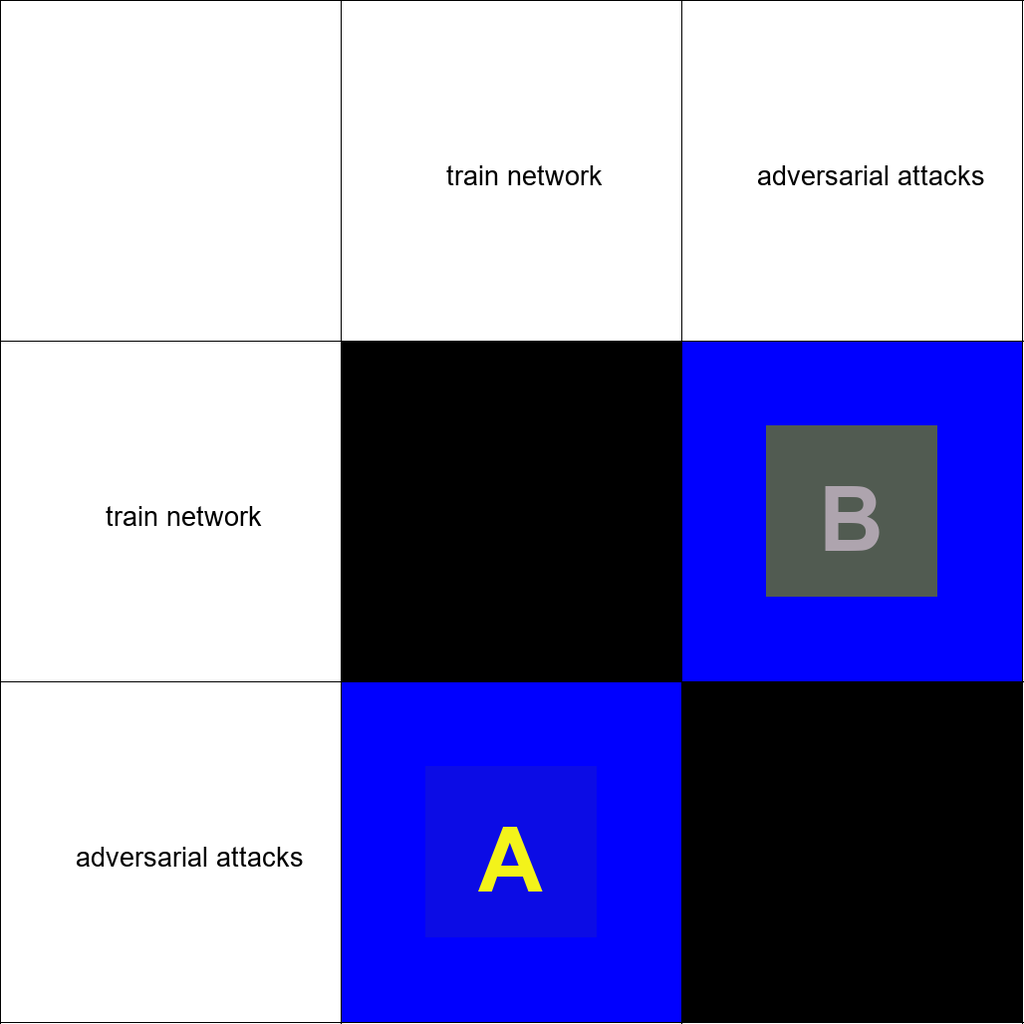

```python
def create_matrix_image(base_matrix, components):
    N = len(components) + 1
    img_size = 1028
    cell_size = img_size // N

    image = Image.new("RGB", (img_size, img_size), "white")
    draw = ImageDraw.Draw(image)
    font = ImageFont.truetype("arial.ttf", 27)
    bold_font = ImageFont.truetype("arialbd.ttf", 90)  # Bold font for deficiency grade


    # Draw the problem_standalone_components names
    for i, component in enumerate(components):
        draw.text((cell_size * (i + 1) + cell_size // 2 - 5 * len(component), cell_size // 2 - 10), component, font=font, fill="black")
        draw.text((cell_size // 2 - 5 * len(component), cell_size * (i + 1) + cell_size // 2 - 10), component, font=font, fill="black")

    # Draw the matrix
    for row, col in itertools.product(components, repeat=2):
        i = components.index(row)
        j = components.index(col)

        pair = next((p for p in base_matrix if p["source"] == row and p["sink"] == col), {})
        source_goal_type = pair.get("source goal type", "")

        if source_goal_type == "inf":
            color = "red"
        elif source_goal_type == "apr":
            color = "green"
        elif source_goal_type == "ctr":
            color = "blue"
        elif source_goal_type == "unclear":
            color = "white"
        else:
            color = "black"

        draw.rectangle([(cell_size * (j + 1), cell_size * (i + 1)), (cell_size * (j + 2), cell_size * (i + 2))], fill=color)

        # Draw the attitude_box
        attitude_tuple = pair.get("attitude tuple (h,u,c)", ())
        if not attitude_tuple or len(attitude_tuple) != 3:
            attitude_color = (0, 0, 0)  # default color
        else:
            h, e, d = attitude_tuple
            attitude_color = (int(255 * h), int(255 * e), int(255 * d))
            print(f"attitude_color = {attitude_color}")


        attitude_box_size = cell_size // 2
        attitude_box_x1 = cell_size * (j + 1) + (cell_size - attitude_box_size) // 2
        attitude_box_y1 = cell_size * (i + 1) + (cell_size - attitude_box_size) // 2
        attitude_box_x2 = attitude_box_x1 + attitude_box_size
        attitude_box_y2 = attitude_box_y1 + attitude_box_size

        draw.rectangle([(attitude_box_x1, attitude_box_y1), (attitude_box_x2, attitude_box_y2)], fill=attitude_color)

        # Draw the deficiency grade
        deficiency_grade = pair.get("deficiency performance grade", "")
        if deficiency_grade:
            # Calculate the opposite color of the attitude_box
            opposite_color = tuple(map(lambda x: 255 - x, attitude_color))
            # Draw the deficiency grade letter in the center of the attitude_box
            deficiency_grade_x = attitude_box_x1 + (attitude_box_size // 2) - (bold_font.getsize(deficiency_grade)[0] // 2)
            deficiency_grade_y = attitude_box_y1 + (attitude_box_size // 2) - (bold_font.getsize(deficiency_grade)[1] // 2)
            draw.text((deficiency_grade_x, deficiency_grade_y), deficiency_grade, font=bold_font, fill=opposite_color)
        # Draw the black borders
        for i in range(N + 1):
            draw.line([(i * cell_size, 0), (i * cell_size, img_size)], fill="black", width=1)
            draw.line([(0, i * cell_size), (img_size, i * cell_size)], fill="black", width=1)

    return image

# clean standalone_components
def clean_list(input_list):
    cleaned_list = []

    for item in input_list:
        cleaned_item = item.strip()
        cleaned_list.append(cleaned_item)

    return cleaned_list

problem_standalone_components = clean_list(problem_standalone_components)

matrix_image = create_matrix_image(the_matrix, problem_standalone_components)

# function that saves an image with the current date and time in the filename
def save_matrix_image(image, base_filename):
    # Get the current date and time
    current_datetime = datetime.now()

    # Format the date and time as desired
    formatted_datetime = current_datetime.strftime("%Y%m%d_%H%M%S")

    # Construct the output filename with date and time
    output_filename = f"{base_filename}_{formatted_datetime}.png"

    # Save the image
    image.save(output_filename)
    print(f"Image saved as {output_filename}")

# Save the image with the date and time in the filename
save_matrix_image(matrix_image, "process_A_complex_problem_appreciation_aic_matrix")

# matrix_image.save("process_A_complex_problem_appreciation_aic_matrix_date190624_time0930.png")

print("process A complex problem articulation AIC_matrix: produced on 19/06/2024")
display(matrix_image)
```

# Step 2.6.2 Code Explanation

### Main Purpose

The main purpose of the `create_matrix_image` function is to generate a visual representation of a matrix that captures the relationships and interactions between different components of a complex problem. This matrix is visualized as an image, with different colors and markings to represent various types of relationships and performance metrics (such as goal types, attitudes, and deficiency grades) between components.

### How It Achieves the Purpose

#### 1. **Initialize Image and Drawing Objects**

- **Image Creation**: The function creates a new image with dimensions `1028x1028` pixels, with a white background.
- **Drawing Context**: An `ImageDraw` object is created to draw on the image.
- **Fonts**: Two fonts are loaded: a regular font for component names and a bold font for deficiency grades.

#### 2. **Draw Component Names**

- **Headers**: The function draws the names of the components along the top row and the leftmost column of the matrix. This allows each cell in the matrix to be identified by its corresponding row and column headers.

#### 3. **Draw Matrix Cells**

- **Iterate Over Pairs**: The function uses `itertools.product` to iterate over all possible pairs of components (both row and column).
- **Coloring Cells**: For each pair, it retrieves the corresponding relationship data from `base_matrix` and determines the `source_goal_type`. It then fills the cell with a color corresponding to this goal type:
  - "inf" -> Red
  - "apr" -> Green
  - "ctr" -> Blue
  - "unclear" -> White
  - Any other value -> Black

#### 4. **Draw Attitude Box**

- **Attitude Colors**: For each cell, it retrieves the `attitude tuple (h,u,c)` (harmony, uncertainty, conflict). It then calculates an `attitude_color` based on these values, where each component of the color is a proportion of 255 (the maximum value for an RGB color component).
- **Positioning**: The attitude box is drawn at the center of each matrix cell.

#### 5. **Draw Deficiency Grade**

- **Retrieve Grade**: If a deficiency grade is available for the current cell, it is drawn at the center of the attitude box.
- **Opposite Color**: The text of the deficiency grade is drawn in the opposite color of the attitude box to ensure visibility.

#### 6. **Draw Borders**

- **Grid Lines**: The function draws black borders to separate each cell in the matrix, enhancing the visual separation and readability of the matrix.

#### 7. **Utility Functions**

- **clean_list**: A helper function that removes leading and trailing spaces from each item in a list of component names.

### Execution Flow

1. **Clean Component List**: The `problem_standalone_components` list is cleaned using the `clean_list` function.
2. **Generate Image**: The `create_matrix_image` function is called with the cleaned list and the matrix data (`the_matrix`).
3. **Save and Display Image**: The generated image is saved to a file and then displayed.

### Example Usage

```
problem_standalone_components = clean_list(problem_standalone_components)
matrix_image = create_matrix_image(the_matrix, problem_standalone_components)
matrix_image.save("process_A_complex_problem_appreciation_aic_matrix_date190624_time0930.png")

print("process A complex problem articulation AIC_matrix: produced on 19/06/2024")
display(matrix_image)
```

This sequence ensures that the matrix is correctly visualized, saved, and displayed, providing a macroscopic view of the complex problem and its articulated relationships.

# Process B) Complex Problem Solution Appreciation

## Step 3) Resolve the Predicted Complicated Situations

## Step 3.1) Re-architect Stand-alone Problem Complex

Add your solution componets into the mix and predict the standalone complex to what you desire to be due to the eddition of the solution. Make sure you update the used complex set to include what you have identified in your predicted complicated situations.

```python
# Update the complex with your added solution
# solution_standalone_components = problem_standalone_components + ['eagle robot']
solution_standalone_components = ['train network', 'adversarial attacks', 'eagle robot']

print(solution_standalone_components )
```

```
['train network', 'adversarial attacks', 'eagle robot']
```

Useful activities to help with defining desired used complex for desired purpose for adversarial components: lets take for example:

trespassers used subcomponents in problem domain:

('Camouflage', ' physical attributes', ' human intelligence', ' Counter-Surveillance means', ' Surveillance means', ' communication systems', ' reconnaissance and scouting')('train track zone access points', ' camouflage and concealment equipment', ' physical surveillance and reconnaissance equipment', ' communication systems', ' exit strategies', ' intelligent timing and coordination of movement with train schedules')('Communication devices', ' Covert equipment', ' Surveillance tools', ' Access tools', ' Distraction devices')

The above problem doman should be re-desribed or re-named or re-worded in the solution domain:

1. create a list that captures What is the phrase which express or represents a failed, dysfunctional-device name for to the following phrases?

example:

[Unsuccessful Camouflage, Unsuccessful physical attributes, Unsuccessful human intelligence, Unsuccessful Counter-Surveillance means, Unsuccessful Surveillance means, Unsuccessful communication systems, Unsuccessful reconnaissance and scouting, Unsuccessful train track zone access points, Unsuccessful camouflage and concealment equipment, Unsuccessful physical surveillance and reconnaissance equipment, Unsuccessful communication systems, Unsuccessful exit strategies, Unsuccessful intelligent timing and coordination of movement with train schedules, Unsuccessful Communication devices, Unsuccessful Covert equipment, Unsuccessful Surveillance tools, Unsuccessful Access tools, Unsuccessful Distraction devices]

2. given the list in 1, create a list of the sysnonyms or other phrase that re-describe the folloiwng concepts, what would you call a device or a physical mean that can be possed by a person and be described as:

example:

[Ineffective Disguise, Ineffective Appearance, Ineffective Cognitive Abilities, Ineffective Anti-Surveillance means, Ineffective Monitoring means, Ineffective Connectivity systems, Ineffective Scouting and Observation, Ineffective Train track entry points, Ineffective Concealment equipment, Ineffective Surveillance and Reconnaissance equipment, Ineffective Communication systems, Ineffective Departure plans, Ineffective Timing and Coordination with train schedules, Ineffective Communication devices, Ineffective Covert equipment, Ineffective Monitoring tools, Ineffective Access tools, Ineffective Distraction devices]

```python
solution_component_dict = {}
for component in solution_standalone_components:
    print(f"+++++++++++++ source: {component} ++++++++++++++++++")
    print("-----------------------------------------------------------------------")
    existing_component_info = problem_component_dict.get(component, {})
    if existing_component_info:
        solution_main_purpose = input(f"{component} Q1) given {component}'s current existing main purpose {existing_component_info.get('Main Standalone Influence purpose', 'undefined')}, What is the Desired Main Standalone Influence purpose for {component}: \n\n answer 1) ")
        print("-----------------------------------------------------------------------")
        solution_controllable_subcomponents = input(f"{component} Q2) given {component}'s current components {existing_component_info.get('Controllable Subcomponent', 'undefined')}, What are the desired controllable subcomponents and their desiareable states for {component} that would lead to the manifestation of desired main purpose, separated by commas: \n\n answer 2) ").split(',')
        print("-----------------------------------------------------------------------")
    else:
        solution_main_purpose = input(f"{component} Q1) given {component}'s current existing main purpose (undefined), What is the Desired Main Standalone Influence purpose for {component}: \n\n answer 1) ")
        print("-----------------------------------------------------------------------")
        solution_controllable_subcomponents = input(f"{component} Q2) given {component}'s current components (undefined), What are the desired controllable subcomponents and their desireable states for {component}, that would lead to the manifestation of desired main purpose, separated by commas: \n\n answer 2) ").split(',')
        print("-----------------------------------------------------------------------")

    solution_component_dict[component] = {
        'Resolved Standalone Component': component,
        'Resolved Main Standalone Influence purpose': solution_main_purpose,
        'Resolved Controllable Subcomponent': solution_controllable_subcomponents
    }

# Print the resulting solution_component_dict
print(solution_component_dict)
```

```
+++++++++++++ source: train network ++++++++++++++++++
-----------------------------------------------------------------------
train network Q1) given train network's current existing main purpose to influence train operations for safe and orderly transit of passengers and goods, What is the Desired Main Standalone Influence purpose for train network:

 answer 1) to strengthen the influence (the control) over train operations for safe and orderly transit of passengers and goods
-----------------------------------------------------------------------
train network Q2) given train network's current components ['train track zone', ' train', ' train driver'], What are the desired controllable subcomponents and their desiareable states for train network that would lead to the manifestation of desired main purpose, separated by commas:

 answer 2) Physical barriers,  Surveillance systems,  Security personnel,  Communication systems, cctv,  Emergency Alert Systems,  Collaboration Platforms,  Incident Reporting and Management Tools, eagle robot
-----------------------------------------------------------------------
+++++++++++++ source: adversarial attacks ++++++++++++++++++
-----------------------------------------------------------------------
adversarial attacks Q1) given adversarial attacks's current existing main purpose (undefined), What is the Desired Main Standalone Influence purpose for adversarial attacks:

 answer 1) not to influence train network operations
-----------------------------------------------------------------------
adversarial attacks Q2) given adversarial attacks's current components (undefined), What are the desired controllable subcomponents and their desireable states for adversarial attacks, that would lead to the manifestation of desired main purpose, separated by commas:

 answer 2) Malfunctioning Drone, Incompetent Pilot, Dysfunctional Drone Swarm, Inept Pilot Group, Faulty Train Track Zone, Flawed Train Track Zone Open Space, Defective Outer Area of Train Track Zone
-----------------------------------------------------------------------
+++++++++++++ source: eagle robot ++++++++++++++++++
-----------------------------------------------------------------------
eagle robot Q1) given eagle robot's current existing main purpose (undefined), What is the Desired Main Standalone Influence purpose for eagle robot:

 answer 1) to enhance control and monitoring capabilities for improved security and safety in the train track zone.
-----------------------------------------------------------------------
eagle robot Q2) given eagle robot's current components (undefined), What are the desired controllable subcomponents and their desireable states for eagle robot, that would lead to the manifestation of desired main purpose, separated by commas:

 answer 2) intelligent eagle drone, intelligent eagle nest (drone docking station).
-----------------------------------------------------------------------
{'train network': {'Resolved Standalone Component': 'train network', 'Resolved Main Standalone Influence purpose': 'to strengthen the influence (the control) over train operations for safe and orderly transit of passengers and goods', 'Resolved Controllable Subcomponent': ['Physical barriers', '  Su…
```

# Step 3.1 Code Explanation

## The above code is a Systems Thinking based Chain-of-Thought (CoT), aims to Prompt the intelligent-system architect's predictive thinking capability to define the desired relationships among systems where the solution is present.

The code above collects user inputs to define and document the desired purposes and controllable subcomponents for a set of standalone components in a system. It processes each component, captures its main purpose and subcomponents based on the user inputs, and stores this information in a dictionary for later use.

**Detailed Explanation:**

1. **Initialization:**
   - `solution_component_dict = {}`: Initializes an empty dictionary to store the resolved information for each component.
2. **Iterating through Components:**
   - `for component in solution_standalone_components:`: Iterates over each component in the `solution_standalone_components` list.
3. **Displaying Component Information:**
   - Prints the component being processed and a separator line for clarity in the output.
4. **Fetching Existing Component Information:**
   - `existing_component_info = problem_component_dict.get(component, {})`: Retrieves existing information about the component from `problem_component_dict`. If the component does not exist in the dictionary, it defaults to an empty dictionary.
5. **User Input for Main Purpose and Subcomponents:**
   - If `existing_component_info` is not empty, the script asks the user to provide:
     - The desired main purpose of the component (`solution_main_purpose`), given its current purpose from `existing_component_info`.
     - The desired controllable subcomponents (`solution_controllable_subcomponents`), given its current subcomponents from `existing_component_info`.
   - If `existing_component_info` is empty, it prompts the user similarly but without any predefined current purpose or subcomponents.
6. **Storing Resolved Information:**
   - The collected information (`solution_main_purpose` and `solution_controllable_subcomponents`) is stored in `solution_component_dict` for each component.
7. **Output:**
   - Finally, the code prints the `solution_component_dict`, which contains the resolved purposes and subcomponents for each component.

**Example Breakdown:**

For the component "train network":

- The current main purpose is provided ("to influence train operations for safe and orderly transit of passengers and goods"), and the user is prompted to specify the desired main purpose.
- The current subcomponents ("train track zone", "train", "train driver") are provided, and the user specifies the desired subcomponents and their states.
- This information is stored in the dictionary under the key "train network".

For the component "adversarial attacks":

- No existing information is provided, so the user inputs both the desired main purpose and the desired subcomponents from scratch.
- This information is stored under the key "adversarial attacks".

For the component "eagle robot":

- Similar to "adversarial attacks", no existing information is provided. The user inputs the desired main purpose and subcomponents.
- This information is stored under the key "eagle robot".

**Result:** The `solution_component_dict` dictionary now holds structured information about the desired purposes and subcomponents for each component, facilitating further processing or analysis.

```python
# Create list of binary related components
solution_complex_combinations = []
for i in range(len(solution_standalone_components)):
    for j in range(len(solution_standalone_components)):
        if i != j:
            combination = {"source": solution_standalone_components[i], "sink": solution_standalone_components[j]}
            solution_complex_combinations.append(combination)
print(solution_complex_combinations)
```

```
[{'source': 'train network', 'sink': 'adversarial attacks'}, {'source': 'train network', 'sink': 'eagle robot'}, {'source': 'adversarial attacks', 'sink': 'train network'}, {'source': 'adversarial attacks', 'sink': 'eagle robot'}, {'source': 'eagle robot', 'sink': 'train network'}, {'source': 'eagle…
```

you could directly change the colors of the as-is AIC-Matrix, or follow the thinking script below. Consider what you desire to happen to the complex problem after you add your solution. This will impose on the solution some requirement to ensure your desired complex behaviours are reinforced.

## Step 3.2) Re-define Complicatedness decomposition to what you predict them to be and what you desire

#### First the archietct have to rdefine their desired intent over sourc's behavour and and they predict the sinks behavours in every compelx behaviour will be

```python
# Function to prompt for new source and sink combinations. add the desired solution and the combinations woith ther rest of teh problem systems
# Function to add new source and sink with "unclear" values for the rest of the columns
def add_solution(df):
    while True:
        new_source = input("Enter the new solution source (or type 'stop' to finish): ")
        if new_source.lower() == 'stop':
            break
        new_sink = input("Enter the new sink for the solution source: ")

        # Create a new row with "unclear" values for the rest of the columns
        new_row = {
            "source": new_source,
            "sink": new_sink,
            "source goal": "unclear",
            "source goal explanation": "unclear",
            "source goal type": "unclear",
            "source goal type explanation": "unclear",
            "source goal effect type": "unclear",
            "source goal effect type explanation": "unclear",
            "source capability action": "unclear",
            "source capability action explanation": "unclear",
            "source capability action type": "unclear",
            "source capability action type explanation": "unclear",
            "source capability effect type": "unclear",
            "source capability effect type Explanation": "unclear",
            "source's used complex": "unclear",
            "source's used complex explanation": "unclear"
        }

        # Append the new row to the DataFrame using pd.concat
        df = pd.concat([df, pd.DataFrame([new_row])], ignore_index=True)

    return df

# Add new solutions to the DataFrame
df_combinations = add_solution(df_combinations)

# Display the updated DataFrame
print(df_combinations)
```

```
Enter the new solution source (or type 'stop' to finish): eagle robot
Enter the new sink for the solution source: train network
Enter the new solution source (or type 'stop' to finish): eagle robot
Enter the new sink for the solution source: adversarial attacks
Enter the new solution source (or type 'stop' to finish): adversarial attacks
Enter the new sink for the solution source: eagle robot
Enter the new solution source (or type 'stop' to finish): train network
Enter the new sink for the solution source: eagle robot
Enter the new solution source (or type 'stop' to finish): stop
                source                 sink
0        train network  adversarial attacks  \
1        train network  adversarial attacks
2  adversarial attacks        train network
3          eagle robot        train network
4          eagle robot  adversarial attacks
```

[output cut: 148 more lines]

# Step 3.2 Code Explanation

The primary functionality of the above code is to prompt the user to input new source and sink combinations for a solution, fill the rest of the DataFrame with "unclear" values for these combinations, and append these new combinations to an existing DataFrame. The process continues until the user decides to stop by typing 'stop'. Finally, the updated DataFrame is displayed.

### Detailed Explanation

1. **Function Definition**:
   - The function `add_solution` is defined, which takes a DataFrame (`df`) as an argument.
2. **User Input Loop**:
   - A `while` loop is initiated, which runs indefinitely until the user decides to stop.
   - Inside the loop, the user is prompted to enter a new source for the solution. If the user types 'stop', the loop breaks, and the function exits.
   - If the user does not type 'stop', they are then prompted to enter a new sink for the solution source.
3. **Creating a New Row**:
   - After receiving the source and sink input, a new dictionary (`new_row`) is created with the source and sink values provided by the user.
   - All other fields in the dictionary are filled with the value "unclear".
4. **Appending the New Row**:
   - The new row (a dictionary) is converted to a DataFrame with a single row.
   - The new row DataFrame is appended to the existing DataFrame (`df`) using the `pd.concat` function. The `ignore_index=True` parameter ensures that the index is reset in the resulting DataFrame, preventing index duplication.
5. **Returning the Updated DataFrame**:
   - Once the user types 'stop' and exits the loop, the updated DataFrame is returned from the function.
6. **Updating the DataFrame**:
   - The `add_solution` function is called with the existing DataFrame (`df_combinations`), and the result is assigned back to `df_combinations`.
   - This ensures that `df_combinations` is updated with the new source and sink combinations provided by the user.
7. **Displaying the Updated DataFrame**:
   - The updated DataFrame is printed, displaying all the entries, including the newly added rows with "unclear" values.

### How It Achieves the Goal

- **User Interaction**: The code engages the user in an interactive loop to gather inputs for new source and sink combinations.
- **Data Integrity**: It maintains data integrity by appending new rows with the required structure and filling unspecified fields with "unclear".
- **Dynamic Data Update**: The DataFrame is dynamically updated within the function, ensuring all new entries are included before the final output.
- **Stopping Condition**: The loop provides a clear mechanism to stop further input, ensuring the function exits gracefully and returns the updated DataFrame.

```python
# ensure that df_combinations is clean for the next step
print("df_combinations:")
print(df_combinations[['source', 'sink']])

print("\nsolution_complex_combinations:")
print(solution_complex_combinations)

# Strip leading/trailing spaces and convert to lowercase for consistency
df_combinations['source'] = df_combinations['source'].str.strip().str.lower()
df_combinations['sink'] = df_combinations['sink'].str.strip().str.lower()
```

```
df_combinations:
                source                 sink
0        train network  adversarial attacks
1        train network  adversarial attacks
2  adversarial attacks        train network
3          eagle robot        train network
4          eagle robot  adversarial attacks
5  adversarial attacks          eagle robot
6        train network          eagle robot

solution_complex_combinations:
[{'source': 'train network', 'sink': 'adversarial attacks'}, {'source': 'train network', 'sink': 'eagle robot'}, {'source': 'adversarial attacks', 'sink': 'train network'}, {'source': 'adversarial attacks', 'sink': 'eagle robot'}, {'source': 'eagle robot', 'sink': 'train network'}, {'source': 'eagle…
```

```python
# Loop over the combinations
#for goal and capability or action context, choose apr, inf, ctr [which are equivalent to Appreciation, Influence, Control]
#for effect, choose [deny, circumvent, ignore, reinforce]
for combination in solution_complex_combinations:
    if df_combinations[(df_combinations['source'] == combination['source']) &
                   (df_combinations['sink'] == combination['sink'])].empty:
        print(f"Combination {combination['source']} -> {combination['sink']} not found in df_combinations. Skipping.")
        continue
    # Get the index of the row in df_combinations that matches the current source and sink
    idx = df_combinations[(df_combinations['source'] == combination['source']) &
                          (df_combinations['sink'] == combination['sink'])].index[0]

    # Extract main purpose from problem_component_dict based on source component
    main_purpose = solution_component_dict[combination['source']]["Resolved Main Standalone Influence purpose"]
    sink_main_purpose = solution_component_dict[combination['sink']]["Resolved Main Standalone Influence purpose"]
    # Ask user to input data fields for the current combination.
    print(f"+++++++++++++ source: {combination['source']} vs sink: {combination['sink']} ++++++++++++++++++")
    # Ask user to input data fields for the current combination to input the desired source goal state
    existing_source_goal = df_combinations.loc[(df_combinations['source'] == combination['source']) & (df_combinations['sink'] == combination['sink']), 'source goal'].values[0]
    desired_source_goal = input(f" {combination['source']} -> {combination['sink']} Q15) Desired change for source goal: Given the current value of source goal ({existing_source_goal}), what is the desired change?: \n\n Answer 15) ")
    print("")
    explain_desired_source_goal = input(f" {combination['source']} -> {combination['sink']} Q16) explain_desired_source_goal: given {combination['source']} as source -> {combination['sink']} as sink, explain the rationale behind the desired change of {desired_source_goal}: \n\n Answer 16)  ")
    print("-----------------------------------------------------------------------")

    # Ask user to input data fields for the current combination to input the desired source goal type
    existing_source_goal_type = df_combinations.loc[(df_combinations['source'] == combination['source']) & (df_combinations['sink'] == combination['sink']), 'source goal type'].values[0]
    desired_source_goal_type = input(f" {combination['source']} -> {combination['sink']}  Q17) Desired change for source goal type: Given the current value of source goal type ({existing_source_goal_type}), what is the desired change?: \n\n Answer 17) ")
    print("")

    explain_desired_source_goal_type = input(f" {combination['source']} -> {combination['sink']}  Q18) explain_desired_source_goal_type: given {combination['source']} as source -> {combination['sink']} as sink, explain the rationale behind the desired change of {desired_source_goal_type}:\n\n Answer 18)  ")
    print("-----------------------------------------------------------------------")

    # Ask user to input data fields for the current combination to input the desired source goal effect type
    existing_source_goal_effect_type = df_combinations.loc[(df_combinations['source'] == combination['source']) & (df_combinations['sink'] == combination['sink']), 'source goal effect type'].values[0]
    desired_source_goal_effect_type = input(f" {combination['source']} -> {combination['sink']}  Q19) Desired change for source goal effect type: Given the current value of source goal effect type ({existing_source_goal_effect_type}), what is the desired change? \n\n Answer 19) ")
    print("")

    explain_desired_source_goal_effect_type = input(f" {combination['source']} -> {combination['sink']}  Q20) explain_desired_source_goal_effect_type: given {combination['source']} as source -> {combination['sink']} as sink, explain the rationale behind the desired change of {desired_source_goal_effect_type}: \n\n Answer 20) ")
    print("-----------------------------------------------------------------------")

    # Ask user to input data fields for the current combination to input the desired source capability action
    existing_source_capability_action = df_combinations.loc[(df_combinations['source'] == combination['source']) & (df_combinations['sink'] == combination['sink']), 'source capability action'].values[0]
    desired_source_capability_action = input(f" {combination['source']} -> {combination['sink']}  Q21) Desired change for source capability action: Given the current value of source capability action ({existing_source_capability_action}), what is the desired change? \n\n Answer 21) ")
    print("")

    explain_desired_source_capability_action = input(f" {combination['source']} -> {combination['sink']}  Q22) explain_desired_source_capability_action: given {combination['source']} as source -> {combination['sink']} as sink, explain the rationale behind the desired change of {desired_source_capability_action}:\n\n Answer 22)  ")
    print("-----------------------------------------------------------------------")

    # Ask user to input data fields for the current combination to input the desired source capability action type
    existing_source_capability_type = df_combinations.loc[(df_combinations['source'] == combination['source']) & (df_combinations['sink'] == combination['sink']), 'source capability action type'].values[0]
    desired_source_capability_type = input(f"{combination['source']} -> {combination['sink']}  Q23) Desired change for source capability action type: Given the current value of source capability action type ({existing_source_capability_type}), what is the desired change?: \n\n Answer 23) ")
    print("")

    explain_desired_source_capability_type = input(f"{combination['source']} -> {combination['sink']}  Q24) explain_desired_source_capability_type: given {combination['source']} as source -> {combination['sink']} as sink, explain the rationale behind the desired change of {desired_source_capability_type}: \n\n Answer 24)  ")
    print("-----------------------------------------------------------------------")

    # Ask user to input data fields for the current combination to input the desired source capability effect type
    existing_source_capability_effect_type = df_combinations.loc[(df_combinations['source'] == combination['source']) & (df_combinations['sink'] == combination['sink']), 'source capability effect type'].values[0]
    desired_source_capability_effect_type = input(f"{combination['source']} -> {combination['sink']}  Q25) Desired change for source capability effect type: Given the current value of source capability effect type ({existing_source_capability_effect_type}), what is the desired change? \n\n Answer 25) ")
    print("")

    explain_desired_source_capability_effect_type = input(f"{combination['source']} -> {combination['sink']}  Q26) explain_desired_source_capability_effect_type: given {combination['source']} as source -> {combination['sink']} as sink, explain the rationale behind the desired change of {desired_source_capability_effect_type}:\n\n Answer 26)  ")
    print("-----------------------------------------------------------------------")

    # Ask user to input data fields for the current combination to input the desired source used complex
    existing_source_used_complex = df_combinations.loc[(df_combinations['source'] == combination['source']) & (df_combinations['sink'] == combination['sink']), "source's used complex"].values[0]
    desired_source_used_complex = input(f"{combination['source']} -> {combination['sink']}  Q27) Desired change for source used complex: Given the current value of source used complex ({existing_source_used_complex}), what is the desired change?: \n\n Answer 27) ")
    print("")

    explain_desired_source_used_complex = input(f"{combination['source']} -> {combination['sink']}  Q28) explain_desired_source_used_complex: given {combination['source']} as source -> {combination['sink']} as sink, explain the rationale behind the desired change of {desired_source_used_complex}: ")
    print("--------------------------------------")

    # Append the data to the DataFrame
    new_row = {
        "desired source goal": desired_source_goal,
        "desired source goal explanation": explain_desired_source_goal,
        "desired source goal type": desired_source_goal_type,
        "desired source goal type explanation": explain_desired_source_goal_type,
        "desired source goal effect type": desired_source_goal_effect_type,
        "desired source goal effect type explanation": explain_desired_source_goal_effect_type,
        "desired source capability action": desired_source_capability_action,
        "desired source capability action explanation": explain_desired_source_capability_action,
        "desired source capability action type": desired_source_capability_type,
        "desired source capability action type explanation": explain_desired_source_capability_type,
        "desired source capability effect type": desired_source_capability_effect_type,
        "desired source capability effect type explanation": explain_desired_source_capability_effect_type,
        "desired source's used complex": desired_source_used_complex,
        "desired source's used complex explanation": explain_desired_source_used_complex
    }

    # Add the new row to df_combinations at the appropriate index
    for key in new_row:
        df_combinations.loc[idx, key] = new_row[key]
```

```
+++++++++++++ source: train network vs sink: adversarial attacks ++++++++++++++++++
 train network -> adversarial attacks Q15) Desired change for source goal: Given the current value of source goal (To counter and neutralize adversarial attacks), what is the desired change?:

 Answer 15) To further ensure effective counter and neutralize adversarial attacks.

 train network -> adversarial attacks Q16) explain_desired_source_goal: given train network as source -> adversarial attacks as sink, explain the rationale behind the desired change of To further ensure effective counter and neutralize adversarial attacks.:

 Answer 16)  to enhance the train network's resilience by not only preventing disruptions but also efficiently handling any residual effects of adversarial activities to ensure continuous safe and orderly transit of passengers and goods.
-----------------------------------------------------------------------
 train network -> adversarial attacks  Q17) Desired change for source goal type: Given the current value of source goal type (ctr), what is the desired change?:

 Answer 17) ctr

 train network -> adversarial attacks  Q18) explain_desired_source_goal_type: given train network as source -> adversarial attacks as sink, explain the rationale behind the desired change of ctr:

 Answer 18)  to enhance further control over adversarial attacks.
-----------------------------------------------------------------------
 train network -> adversarial attacks  Q19) Desired change for source goal effect type: Given the current value of source goal effect type (circumvent), what is the desired change?

 Answer 19) deny

 train network -> adversarial attacks  Q20) explain_desired_source_goal_effect_type: given train network as source -> adversarial attacks as sink, explain the rationale behind the desired change of deny:

 Answer 20) to inhibit attacks.
-----------------------------------------------------------------------
 train network -> adversarial attacks  Q21) Desired change for source capability action: Given the current value of source capability action (unclear), what is the desired change?

 Answer 21) o	Adversarial Drone Detection: Use machine learning algorithms and data from the surveillance systems to quickly identify potential drone threats. o	Adversarial Drone Neutralization: Deploy countermeasures like drone jamming equipment to disrupt the drone's communications, potentially ca…

 train network -> adversarial attacks  Q22) explain_desired_source_capability_action: given train network as source -> adversarial attacks as sink, explain the rationale behind the desired change of o	Adversarial Drone Detection: Use machine learning algorithms and data from the surveillance systems…

 Answer 22)  critical capabilities to deny adversarial drone intrusion.
-----------------------------------------------------------------------
train network -> adversarial attacks  Q23) Desired change for source capability action type: Given the current value of source capability action type (unclear), what is the desired change?:

 Answer 23) ctr

train network -> adversarial attacks  Q24) explain_desired_source_capability_type: given train network as source -> adversarial attacks as sink, explain the rationale behind the desired change of ctr:

 Answer 24)  it has to be physically denied access.
```

[output cut: 275 more lines]

```
-----------------------------------------------------------------------
eagle robot -> adversarial attacks  Q25) Desired change for source capability effect type: Given the current value of source capability effect type (unclear), what is the desired change?

 Answer 25) deny

eagle robot -> adversarial attacks  Q26) explain_desired_source_capability_effect_type: given eagle robot as source -> adversarial attacks as sink, explain the rationale behind the desired change of deny:

 Answer 26)  tbd
-----------------------------------------------------------------------
eagle robot -> adversarial attacks  Q27) Desired change for source used complex: Given the current value of source used complex (unclear), what is the desired change?:

 Answer 27) eagle drone

eagle robot -> adversarial attacks  Q28) explain_desired_source_used_complex: given eagle robot as source -> adversarial attacks as sink, explain the rationale behind the desired change of eagle drone: tbd
--------------------------------------
```

# Step 3.2 Code Explanation

## The above code is a Systems Thinking based Chain-of-Thought (CoT), aims to Prompt the intelligent-system architect's predictive thinking capability to define the desired relationships among systems where the solution is present.

This code facilitates interactive input from the user to update the `df_combinations` DataFrame with detailed information for each combination of source and sink. The process involves checking for the existence of the combination in the DataFrame, prompting the user for necessary data, and updating the DataFrame with this new information. This approach ensures that the DataFrame is dynamically populated with relevant and user-specific data based on the combinations provided.

The code iterates over a list of `solution_complex_combinations`, which consists of source and sink combinations. For each combination, it checks if the combination exists in a DataFrame `df_combinations`. If the combination exists, it prompts the user to input various data fields related to that combination and updates the DataFrame accordingly.

### How It Works

1. **Iteration Over Combinations:**

   ```
   for combination in solution_complex_combinations:
   ```

   The loop iterates over each combination in the `solution_complex_combinations` list.
2. **Check if Combination Exists:**

   ```
   if df_combinations[(df_combinations['source'] == combination['source']) &
                      (df_combinations['sink'] == combination['sink'])].empty:
       print(f"Combination {combination['source']} -> {combination['sink']} not found in df_combinations. Skipping.")
       continue
   ```

   For each combination, it checks if the combination exists in `df_combinations`. If not, it prints a message and skips to the next combination.
3. **Get Index of Existing Combination:**

   ```
   idx = df_combinations[(df_combinations['source'] == combination['source']) &
                         (df_combinations['sink'] == combination['sink'])].index[0]
   ```

   If the combination exists, it retrieves the index of the row in `df_combinations` that matches the current source and sink.
4. **Extract Main Purpose:**

   ```
   main_purpose = solution_component_dict[combination['source']]["Resolved Main Standalone Influence purpose"]
   sink_main_purpose = solution_component_dict[combination['sink']]["Resolved Main Standalone Influence purpose"]
   ```

   It extracts the main purpose of the source and sink components from `solution_component_dict`.
5. **Prompt User for Input:**

   ```
   print(f"+++++++++++++ source: {combination['source']} vs sink: {combination['sink']} ++++++++++++++++++")
   ```

   It prints the source and sink combination to the console.
6. **User Inputs for Desired Changes:** For each required field, it asks the user to input the desired change and explanation. For example:

   ```
   existing_source_goal = df_combinations.loc[(df_combinations['source'] == combination['source']) &
                                              (df_combinations['sink'] == combination['sink']), 'source goal'].values[0]
   desired_source_goal = input(f" {combination['source']} -> {combination['sink']} Q15) Desired change for source goal: Given the current value of source goal ({existing_source_goal}), what is the desired change?: \n\n Answer 15) ")
   ```

   It gets the existing value from `df_combinations` and asks the user for the desired change.
7. **Store User Inputs:** For each input, it stores the user-provided value in a new dictionary:

   ```
   new_row = {
       "desired source goal": desired_source_goal,
       "desired source goal explanation": explain_desired_source_goal,
       "desired source goal type": desired_source_goal_type,
       "desired source goal type explanation": explain_desired_source_goal_type,
       "desired source goal effect type": desired_source_goal_effect_type,
       "desired source goal effect type explanation": explain_desired_source_goal_effect_type,
       "desired source capability action": desired_source_capability_action,
       "desired source capability action explanation": explain_desired_source_capability_action,
       "desired source capability action type": desired_source_capability_type,
       "desired source capability action type explanation": explain_desired_source_capability_type,
       "desired source capability effect type": desired_source_capability_effect_type,
       "desired source capability effect type explanation": explain_desired_source_capability_effect_type,
       "desired source's used complex": desired_source_used_complex,
       "desired source's used complex explanation": explain_desired_source_used_complex
   }
   ```

8. **Update DataFrame:** It updates the DataFrame `df_combinations` with the new values provided by the user:

## Step 3.3) Re-evaluate the Attitude of the Predicted and Desired Complicatedness

```python
# define the attitudes for each effect type
attitudes = {
    "deny": {"harmony": 0.05, "uncertainty": 0.05, "conflict": 0.90},
    "reinforce": {"harmony": 0.90, "uncertainty": 0.05, "conflict": 0.05},
    "circumvent": {"harmony": 0.30, "uncertainty": 0.40, "conflict": 0.30},
    "ignore": {"harmony": 0.20, "uncertainty": 0.60, "conflict": 0.20},
    "unclear": {"harmony": 0.33, "uncertainty": 0.33, "conflict": 0.33},
}

# function to compute overall attitude
def compute_predicted_attitude(row):
    source_goal_effect_type = row["desired source goal effect type"]
    source_capability_effect_type = row["desired source capability effect type"]
    # Skip missing data
    if pd.isnull(source_goal_effect_type) or pd.isnull(source_capability_effect_type):
        return {
            "desired attitude_type": None,
            "desired attitude_tuple": None
        }

    effect_types = [
        source_goal_effect_type,
        source_capability_effect_type,

    ]

    total_harmony = 0
    total_uncertainty = 0
    total_conflict = 0

    for effect_type in effect_types:
        total_harmony += attitudes[effect_type]["harmony"]
        total_uncertainty += attitudes[effect_type]["uncertainty"]
        total_conflict += attitudes[effect_type]["conflict"]

    avg_harmony = round(total_harmony / len(effect_types),2)
    avg_uncertainty = round(total_uncertainty / len(effect_types),2)
    avg_conflict = round(total_conflict / len(effect_types),2)

    attitude_tuple = (avg_harmony,avg_uncertainty, avg_conflict)

    if avg_harmony > avg_uncertainty + avg_conflict:
        attitude_type = "in Harmony"
    elif avg_conflict > avg_harmony + avg_uncertainty:
        attitude_type = "in conflict"
    else:
        if avg_harmony > avg_conflict:
            attitude_type = "uncertain leaning towards being in Harmony"
        elif avg_conflict > avg_harmony:
            attitude_type = "uncertain leaning towards being in conflict"
        else:
            attitude_type = "uncertain"


    return {
        "desired attitude_type": attitude_type,
        "desired attitude_tuple": attitude_tuple,
    }

# apply the attitude analysis for every source and sink
df_combinations["desired attitude"] = df_combinations.apply(lambda row: compute_predicted_attitude(row)["desired attitude_type"], axis=1)
# apply the attitude analysis for every source and sink and create a new column for attitude_tuple
df_combinations["desired attitude tuple (h,u,c)"] = df_combinations.apply(lambda row: compute_predicted_attitude(row)["desired attitude_tuple"], axis=1)
```

# Step 3.3 Code Explanation

The main purpose of the given code is to re-evaluate the attitudes associated with the predicted and desired complex behaviors based on the changes in the source goal effect type and source capability effect type. It calculates and categorizes these attitudes to determine how the overall behavior of the system will be influenced by these changes.

### Explanation of How It Achieves This

1. **Define the Attitudes for Each Effect Type**:

   ```
   attitudes = {
       "deny": {"harmony": 0.05, "uncertainty": 0.05, "conflict": 0.90},
       "reinforce": {"harmony": 0.90, "uncertainty": 0.05, "conflict": 0.05},
       "circumvent": {"harmony": 0.30, "uncertainty": 0.40, "conflict": 0.30},
       "ignore": {"harmony": 0.20, "uncertainty": 0.60, "conflict": 0.20},
       "unclear": {"harmony": 0.33, "uncertainty": 0.33, "conflict": 0.33},
   }
   ```

   - This dictionary defines the proportions of harmony, uncertainty, and conflict for different types of effects.
2. **Compute Predicted Attitude Function**:

   ```
   def compute_predicted_attitude(row):
       source_goal_effect_type = row["desired source goal effect type"]
       source_capability_effect_type = row["desired source capability effect type"]
       # Skip missing data
       if pd.isnull(source_goal_effect_type) or pd.isnull(source_capability_effect_type):
           return {
               "desired attitude_type": None,
               "desired attitude_tuple": None
           }

       effect_types = [
           source_goal_effect_type,
           source_capability_effect_type,
       ]

       total_harmony = 0
       total_uncertainty = 0
       total_conflict = 0

       for effect_type in effect_types:
           total_harmony += attitudes[effect_type]["harmony"]
           total_uncertainty += attitudes[effect_type]["uncertainty"]
           total_conflict += attitudes[effect_type]["conflict"]

       avg_harmony = round(total_harmony / len(effect_types), 2)
       avg_uncertainty = round(total_uncertainty / len(effect_types), 2)
       avg_conflict = round(total_conflict / len(effect_types), 2)

       attitude_tuple = (avg_harmony, avg_uncertainty, avg_conflict)

       if avg_harmony > avg_uncertainty + avg_conflict:
           attitude_type = "in Harmony"
       elif avg_conflict > avg_harmony + avg_uncertainty:
           attitude_type = "in conflict"
       else:
           if avg_harmony > avg_conflict:
               attitude_type = "uncertain leaning towards being in Harmony"
           elif avg_conflict > avg_harmony:
               attitude_type = "uncertain leaning towards being in conflict"
           else:
               attitude_type = "uncertain"

       return {
           "desired attitude_type": attitude_type,
           "desired attitude_tuple": attitude_tuple,
       }
   ```

   - This function calculates the overall attitude (harmony, uncertainty, conflict) for a given row based on the desired source goal effect type and source capability effect type.
   - It skips rows with missing data.
   - It computes the average harmony, uncertainty, and conflict from the provided effect types.
   - It determines the attitude type (in Harmony, in conflict, uncertain leaning towards being in Harmony or conflict, or uncertain).
3. **Apply the Function to the DataFrame**:

   ```
   # apply the attitude analysis for every source and sink
   df_combinations["desired attitude"] = df_combinations.apply(lambda row: compute_predicted_attitude(row)["desired attitude_type"], axis=1)
   # apply the attitude analysis for every source and sink and create a new column for attitude_tuple
   df_combinations["desired attitude tuple (h,u,c)"] = df_combinations.apply(lambda row: compute_predicted_attitude(row)["desired attitude_tuple"], axis=1)
   ```

   - The function `compute_predicted_attitude` is applied to each row of the DataFrame `df_combinations`.
   - The first `apply` call adds a new column `desired attitude` to the DataFrame, containing the computed attitude type for each row.
   - The second `apply` call adds another column `desired attitude tuple (h,u,c)` to the DataFrame, containing the computed attitude tuple (harmony, uncertainty, conflict) for each row.

By using this process, the code re-evaluates and updates the attitudes for each combination of source and sink components based on the desired changes, allowing for a more detailed understanding of the potential impacts and interactions within the system.

## Step 3.4) Re-evaluate the Deficiency of the desired behaviours.

```python
# define the deficiency for each effect type
attitudes = {
    "deny": {"harmony": 0.05, "uncertainty": 0.05, "conflict": 0.90},
    "reinforce": {"harmony": 0.90, "uncertainty": 0.05, "conflict": 0.05},
    "circumvent": {"harmony": 0.30, "uncertainty": 0.40, "conflict": 0.30},
    "ignore": {"harmony": 0.20, "uncertainty": 0.60, "conflict": 0.20},
    "unclear": {"harmony": 0.33, "uncertainty": 0.33, "conflict": 0.33},
}

# function to compute deficiency performance grade
def compute_deficiency_performance_grade_predicted_behaviour(row):
    source_goal_effect_type = row["desired source goal effect type"]
    source_capability_effect_type = row["desired source capability effect type"]
    # Skip missing data
    if pd.isnull(source_goal_effect_type) or pd.isnull(source_capability_effect_type):
        return {
            "desired grade": None,
            "desired deficiency": None
        }


    effect_types = [
        source_goal_effect_type,
        source_capability_effect_type,

    ]

    total_harmony = 0
    total_uncertainty = 0
    total_conflict = 0

    for effect_type in effect_types:
        total_harmony += attitudes[effect_type]["harmony"]
        total_uncertainty += attitudes[effect_type]["uncertainty"]
        total_conflict += attitudes[effect_type]["conflict"]

    avg_harmony = total_harmony / len(effect_types)
    avg_uncertainty = total_uncertainty / len(effect_types)
    avg_conflict = total_conflict / len(effect_types)

    if avg_harmony > avg_uncertainty + avg_conflict:
        grade = "A"#  grade a deficiency
        deficiency = "Negligibly Deficient"
    elif avg_conflict > avg_harmony + avg_uncertainty:
        grade = "C" #  grade c deficiency
        deficiency = "Deficient"
    else:
        grade = "B"
        deficiency = "Possibly Deficient"

    return {"desired grade":grade, "desired deficiency":deficiency}


# Assuming df_combinations is a DataFrame with the required columns
df_combinations["desired deficiency performance grade"] = df_combinations.apply(lambda row: compute_deficiency_performance_grade_predicted_behaviour(row)["desired grade"], axis=1)
df_combinations["desired deficiency description"] = df_combinations.apply(lambda row: compute_deficiency_performance_grade_predicted_behaviour(row)["desired deficiency"], axis=1)
```

# Step 3.4 Code Explanation

The primary purpose of the above code is to re-evaluate the deficiency of desired behaviors in a complex system by analyzing the harmony, uncertainty, and conflict associated with the "desired source goal effect type" and "desired source capability effect type" for each combination of source and sink components. The code aims to determine a deficiency performance grade and a corresponding deficiency description for each combination, which indicates how well the desired behaviors can manifest in the system.

### How the Code Achieves Its Purpose

1. **Defining Attitudes:**
   - A dictionary named `attitudes` is defined, mapping different effect types (deny, reinforce, circumvent, ignore, unclear) to their associated levels of harmony, uncertainty, and conflict. These values represent how each effect type influences the behavior in terms of these three parameters.
2. **Defining the Deficiency Calculation Function:**
   - A function named `compute_deficiency_performance_grade_predicted_behaviour` is defined to compute the deficiency performance grade for each row in the DataFrame. The function takes a row as input and performs the following steps:
     1. **Extracting Effect Types:**
        - The function extracts the "desired source goal effect type" and "desired source capability effect type" from the input row.
        - If either of these values is missing (`NaN`), the function returns `None` for both the grade and deficiency.
     2. **Summing Attitudes:**
        - The function iterates over the effect types, summing up the corresponding harmony, uncertainty, and conflict values from the `attitudes` dictionary.
     3. **Calculating Averages:**
        - The average values for harmony, uncertainty, and conflict are calculated by dividing the total values by the number of effect types.
     4. **Determining the Deficiency Grade:**
        - The function evaluates the average values to determine the deficiency performance grade:
          - If the average harmony is greater than the sum of average uncertainty and conflict, the grade is set to "A" (Negligibly Deficient).
          - If the average conflict is greater than the sum of average harmony and uncertainty, the grade is set to "C" (Deficient).
          - Otherwise, the grade is set to "B" (Possibly Deficient).
     5. **Returning the Results:**
        - The function returns a dictionary with the determined grade and deficiency description.
3. **Applying the Function to the DataFrame:**
   - The `apply` method is used to apply the `compute_deficiency_performance_grade_predicted_behaviour` function to each row of the DataFrame `df_combinations`.
   - The results are stored in new columns named "desired deficiency performance grade" and "desired deficiency description".

### Summary of Process

- **Input DataFrame (`df_combinations`):**
  - Contains columns with source and sink components, their goals, capabilities, and effect types.
- **Processing:**
  - For each row, extract the desired effect types.
  - Sum the corresponding harmony, uncertainty, and conflict values.
  - Calculate the averages.
  - Determine the deficiency grade based on the averages.
  - Add the results to new columns in the DataFrame.
- **Output:**
  - The updated DataFrame now includes the calculated deficiency performance grade and description for each source-sink combination.

## Step 3.5) Define Architect Complicated Missions

Describe the prediction about the "to-be" behaviour for each cell. And then run a plausibility test by evaluating whether it is "plausible" or "remotely plausible," then justify why you think the prediction is plausible or remotely plausible. Remotely plausible does not mean "impossible," it means it is possible but at this stage, we will accept not to consider it until it plays out in reality. However, we are aware of it. For example, in the context of Adversarial Attack vs Police, we choose an Appreciation context: the architect predicts that the Drone's behaviour in the context of the Police is to be appreciative one. The capabilities exhibited by the Drone that lead to Control Police behaviour shall be neutralized. The behaviour's Deficiency is expected to be downgraded to level c, which means we predict that it is possible to conflict Attack behaviour by reinforce Police behaviours to neutralize it.

```python
# Loop over the combinations in the DataFrame
for index, row in df_combinations.iterrows():

    # Extract the required fields from the current row
    source = row["source"]
    sink = row["sink"]
    desired_source_goal = row["desired source goal"]
    desired_source_goal_type = row["desired source goal type"]
    desired_source_capability_action = row["desired source capability action"]
    desired_source_capability_action_type = row["desired source capability action type"]
    desired_source_goal_effect_type = row["desired source goal effect type"]
    desired_source_capability_effect_type = row["desired source capability effect type"]
    desired_source_used_complex = row["desired source's used complex"]
    desired_attitude = row["desired attitude"]
    desired_deficiency = row["desired deficiency description"]
    # Extract main purpose from problem_component_dict based on source component
    main_purpose = solution_component_dict[source]["Resolved Main Standalone Influence purpose"]
    sink_main_purpose = solution_component_dict[sink]["Resolved Main Standalone Influence purpose"]


    if desired_source_goal_type == "apr" or desired_source_capability_action_type == "apr":
        desired_source_capability_action_type = "appreciation"
        desired_source_goal_type = "appreciation"
    elif desired_source_goal_type == "ctr" or desired_source_capability_action_type == "ctr":
        desired_source_capability_action_type = "control"
        desired_source_goal_type = "control"
    elif desired_source_goal_type == "inf" or desired_source_capability_action_type == "inf":
        desired_source_capability_action_type = "influence"
        desired_source_goal_type = "influence"


    # Construct the Complicatedness tuple
    resolved_complicatedness_factors = (desired_source_goal_type, desired_source_goal_effect_type, desired_source_capability_action_type, desired_source_capability_effect_type)

    # Convert the Complicatedness tuple to a string
    resolved_complicatedness_str = str(resolved_complicatedness_factors)

    # Add the Attitude in Context string as a new column in the DataFrame
    df_combinations.loc[index, "resolved complicated situation tuple"] = resolved_complicatedness_str

    # Construct the desired complicated situation Description
    predicted_complicated_situation_resolution = f"""The architect intends to ensure that the {source} must have the goal of; {desired_source_goal}, [with the intention of {desired_source_goal_type} towards {sink} behaviour]. the architect intends to cause the {source} having a {desired_source_goal_effect_type}-effect , on the {sink} goal's effectiveness, by causing or making the {source} to have the following subcomponents; {desired_source_used_complex}. In this situation, the {source}'s {desired_source_used_complex} actions of; {desired_source_capability_action} (which must demonstrate and exhibit the intention of {desired_source_capability_action_type} towards {sink}), must be caused to have a {desired_source_capability_effect_type}-effect on the {sink}'s actions  ability to manifest {sink}’s goals. The architect intends to make the {source}’s capability of {desired_source_capability_action} by causing the {source} to have the following subcomponents { desired_source_used_complex }, to align the {sink}’s purpose of { sink_main_purpose} to be {desired_attitude} with respect to manifesting {source}’s main purpose of {main_purpose}. The architect intends to cause the interaction of {source} with {sink} in this complicated situation, to render the of {source}’s capability of {desired_source_capability_action} using the following components; { desired_source_used_complex }, to be {desired_deficiency} for manifesting the {source}’s main purpose of {main_purpose}."""
    df_combinations.loc[index, "resolved complicated situation"] = predicted_complicated_situation_resolution

    # Prompt the user to input a plausibility study and add it as a new column in the DataFrame
    plausibility_study = input(f"""What is the plausibility that the complex {source} -> {sink} will be engaged in the
 resolved complicated situation of {resolved_complicatedness_factors}? (plausible/remotely plausible)""")
    df_combinations.loc[index, "resolved complicated situation plausibility study"] = plausibility_study
```

```
What is the plausibility that the complex train network -> adversarial attacks will be engaged in the
 resolved complicated situation of ('control', 'deny', 'control', 'deny')? (plausible/remotely plausible)plausible
What is the plausibility that the complex train network -> adversarial attacks will be engaged in the
 resolved complicated situation of (nan, nan, nan, nan)? (plausible/remotely plausible)plausible
What is the plausibility that the complex adversarial attacks -> train network will be engaged in the
 resolved complicated situation of ('appreciation', 'reinforce', 'appreciation', 'reinforce')? (plausible/remotely plausible)plausible
What is the plausibility that the complex eagle robot -> train network will be engaged in the
 resolved complicated situation of ('control', 'reinforce', 'control', 'reinforce')? (plausible/remotely plausible)plausible
What is the plausibility that the complex eagle robot -> adversarial attacks will be engaged in the
 resolved complicated situation of ('control', 'deny', 'control', 'deny')? (plausible/remotely plausible)plausible
What is the plausibility that the complex adversarial attacks -> eagle robot will be engaged in the
 resolved complicated situation of ('appreciation', 'ignore', 'appreciation', 'ignore')? (plausible/remotely plausible)plausible
What is the plausibility that the complex train network -> eagle robot will be engaged in the
 resolved complicated situation of ('control', 'reinforce', 'control', 'reinforce')? (plausible/remotely plausible)plausible
```

# Step 3.5 Code Explanation

### Purpose of the Above Code

The purpose of the above code is to define and analyze the predicted "to-be" behaviors for each source-sink pair in a system of systems, document these behaviors, and assess their plausibility. The code captures the intended goals, actions, and effects of these behaviors in a structured format, providing a detailed description of the anticipated interactions. Additionally, it includes a step for evaluating whether the predictions are plausible or only remotely plausible.

### How It Achieves the Purpose

#### 1. **Iterating Over Combinations**

The code begins by iterating over each row in the DataFrame `df_combinations`, which contains data about various source-sink pairs and their behaviors:

```
for index, row in df_combinations.iterrows():
```

#### 2. **Extracting Relevant Fields**

For each row, the code extracts necessary fields such as source, sink, desired goals, actions, and effects:

```
source = row["source"]
sink = row["sink"]
desired_source_goal = row["desired source goal"]
desired_source_goal_type = row["desired source goal type"]
desired_source_capability_action = row["desired source capability action"]
desired_source_capability_action_type = row["desired source capability action type"]
desired_source_goal_effect_type = row["desired source goal effect type"]
desired_source_capability_effect_type = row["desired source capability effect type"]
desired_source_used_complex = row["desired source's used complex"]
desired_attitude = row["desired attitude"]
desired_deficiency = row["desired deficiency description"]
```

#### 3. **Extracting Main Purposes**

The main purpose of the source and sink components is retrieved from a dictionary `solution_component_dict`:

```
main_purpose = solution_component_dict[source]["Resolved Main Standalone Influence purpose"]
sink_main_purpose = solution_component_dict[sink]["Resolved Main Standalone Influence purpose"]
```

#### 4. **Normalizing Goal and Action Types**

The goal and action types are normalized to ensure consistency in terminology:

```
if desired_source_goal_type == "apr" or desired_source_capability_action_type == "apr":
    desired_source_capability_action_type = "appreciation"
    desired_source_goal_type = "appreciation"
elif desired_source_goal_type == "ctr" or desired_source_capability_action_type == "ctr":
    desired_source_capability_action_type = "control"
    desired_source_goal_type = "control"
elif desired_source_goal_type == "inf" or desired_source_capability_action_type == "inf":
    desired_source_capability_action_type = "influence"
    desired_source_goal_type = "influence"
```

#### 5. **Constructing the Complicatedness Tuple**

The code constructs a tuple representing the complicatedness factors of the behavior, then converts it to a string and adds it to the DataFrame:

```
resolved_complicatedness_factors = (desired_source_goal_type, desired_source_goal_effect_type, desired_source_capability_action_type, desired_source_capability_effect_type)
resolved_complicatedness_str = str(resolved_complicatedness_factors)
df_combinations.loc[index, "resolved complicated situation tuple"] = resolved_complicatedness_str
```

#### 6. **Creating the Desired Complicated Situation Description**

The code constructs a detailed description of the predicted behavior, specifying goals, actions, effects, and the intended interaction between the source and sink:

```
predicted_complicated_situation_resolution = f"""The architect intends to ensure that the {source} must have the goal of; {desired_source_goal}, [with the intention of {desired_source_goal_type} towards {sink} behaviour]. the architect intends to cause the {source} having a {desired_source_goal_effect_type}-effect , on the {sink} goal's effectiveness, by causing or making the {source} to have the following subcomponents; {desired_source_used_complex}. In this situation, the {source}'s {desired_source_used_complex} actions of; {desired_source_capability_action} (which must demonstrate and exhibit the intention of {desired_source_capability_action_type} towards {sink}), must be caused to have a {desired_source_capability_effect_type}-effect on the {sink}'s actions  ability to manifest {sink}’s goals. The architect intends to make the {source}’s capability of {desired_source_capability_action} by causing the {source} to have the following subcomponents { desired_source_used_complex }, to align the {sink}’s purpose of { sink_main_purpose} to be {desired_attitude} with respect to manifesting {source}’s main purpose of {main_purpose}. The architect intends to cause the interaction of {source} with {sink} in this complicated situation, to render the of {source}’s capability of {desired_source_capability_action} using the following components; { desired_source_used_complex }, to be {desired_deficiency} for manifesting the {source}’s main purpose of {main_purpose}."""
df_combinations.loc[index, "resolved complicated situation"] = predicted_complicated_situation_resolution
```

#### 7. **Plausibility Study**

Finally, the code prompts the user to input a plausibility study, assessing whether the predicted behavior is plausible or remotely plausible, and records this assessment in the DataFrame:

```
plausibility_study = input(f"""What is the plausibility that the complex {source} -> {sink} will be engaged in the resolved complicated situation of {resolved_complicatedness_factors}? (plausible/remotely plausible)""")
df_combinations.loc[index, "resolved complicated situation plausibility study"] = plausibility_study
```

### Summary

The purpose of the above code is to define, describe, and evaluate the predicted "to-be" behaviors for each source-sink pair in a system. It systematically captures detailed information about these behaviors, normalizes terminology, constructs comprehensive descriptions, and assesses the plausibility of each prediction. This process helps in understanding and documenting the expected interactions and outcomes within a complex system.

## Step 3.6) Build the Complex Solution AIC-Matrix: Process B

```python
# assuming df_combinations is a dataframe with the required columns
# we need to add the solution system into problem standalone components
# hence we have solution_standalone_components

complex_solution_standalone_components = ["train network", "adversarial attacks", "eagle robot"]


base_matrix = []

for _, row in df_combinations.iterrows():
    data = {
        "source": row["source"],
        "sink": row["sink"],
        "desired source goal type": row["desired source goal type"],
        "desired deficiency performance grade": row["desired deficiency performance grade"],
        "desired attitude tuple (h,u,c)": row["desired attitude tuple (h,u,c)"],
    }
    base_matrix.append(data)


improved_matrix = []

for source, sink in itertools.product(complex_solution_standalone_components, repeat=2):
    pair = {
        "source": source,
        "sink": sink,
        "desired source goal type": "",
        "desired deficiency performance grade": "",
        "desired attitude tuple (h,u,c)":"",
    }
    improved_matrix.append(pair)

# populate the_matrix with data from the_matrix1
for matrix_pair in improved_matrix:
    for matrix1_pair in base_matrix:
        if matrix_pair["source"] == matrix1_pair["source"] and matrix_pair["sink"] == matrix1_pair["sink"]:
            matrix_pair["desired source goal type"] = matrix1_pair["desired source goal type"]
            matrix_pair["desired deficiency performance grade"] = matrix1_pair["desired deficiency performance grade"]
            matrix_pair["desired attitude tuple (h,u,c)"] = matrix1_pair["desired attitude tuple (h,u,c)"]
            break



# clean the matrix for processing
def clean_matrix(matrix):
    cleaned_matrix = []

    for item in matrix:
        cleaned_item = {}
        for key, value in item.items():
            cleaned_key = key.strip()
            if isinstance(value, str):
                cleaned_value = value.strip()
            else:
                cleaned_value = value
            cleaned_item[cleaned_key] = cleaned_value
        cleaned_matrix.append(cleaned_item)

    return cleaned_matrix

improved_matrix = clean_matrix(improved_matrix)

# print the total number of elements in the_matrix and the_matrix itself
print(f"total number of elements in the_matrix: {len(improved_matrix)}")
print(f"Improved Matrix = {improved_matrix}")
```

```
total number of elements in the_matrix: 9
Improved Matrix = [{'source': 'train network', 'sink': 'train network', 'desired source goal type': '', 'desired deficiency performance grade': '', 'desired attitude tuple (h,u,c)': ''}, {'source': 'train network', 'sink': 'adversarial attacks', 'desired source goal type': 'ctr', 'desired deficiency…
```

```
Image saved as process_B_complex_solution_appreciation_aic_matrix_19_06_2024_185854.png
process B complex solution appreciation AIC Matrix
```

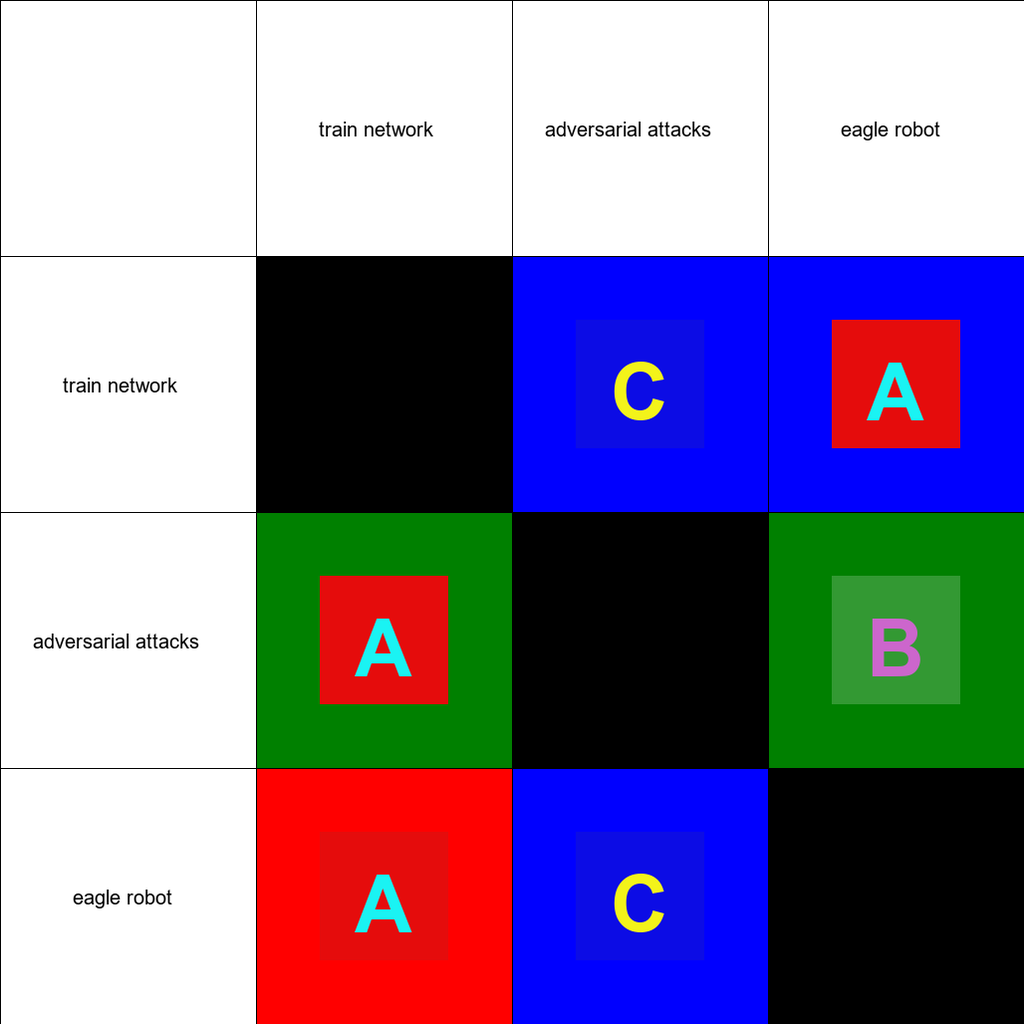

```python
# build improved matrix image
from datetime import datetime

def create_improved_matrix_image(the_matrix1, components):
    N = len(components) + 1
    img_size = 1028
    cell_size = img_size // N

    image = Image.new("RGB", (img_size, img_size), "white")
    draw = ImageDraw.Draw(image)
    font = ImageFont.truetype("arial.ttf", 20)
    bold_font = ImageFont.truetype("arialbd.ttf", 80)  # Bold font for deficiency grade

    # Draw the black borders
    for i in range(N + 1):
        draw.line([(i * cell_size, 0), (i * cell_size, img_size)], fill="black", width=1)
        draw.line([(0, i * cell_size), (img_size, i * cell_size)], fill="black", width=1)

    # Draw the problem_standalone_components names
    for i, component in enumerate(components):
        draw.text((cell_size * (i + 1) + cell_size // 2 - 5 * len(component), cell_size // 2 - 10), component, font=font, fill="black")
        draw.text((cell_size // 2 - 5 * len(component), cell_size * (i + 1) + cell_size // 2 - 10), component, font=font, fill="black")

    # Draw the matrix
    for row, col in itertools.product(components, repeat=2):
        i = components.index(row)
        j = components.index(col)

        pair = next((p for p in the_matrix1 if p["source"] == row.strip() and p["sink"] == col.strip()), {})
        source_goal_type = pair.get("desired source goal type", "")

        if source_goal_type == "inf":
            color = "red"
        elif source_goal_type == "apr":
            color = "green"
        elif source_goal_type == "ctr":
            color = "blue"
        elif source_goal_type == "unclear":
            color = "white"
        else:
            color = "black"

        draw.rectangle([(cell_size * (j + 1), cell_size * (i + 1)), (cell_size * (j + 2), cell_size * (i + 2))], fill=color)

        # Draw the attitude_box
        attitude_tuple = pair.get("desired attitude tuple (h,u,c)", ())
        if not attitude_tuple:
            attitude_color = "black"
        else:
            h, e, d = attitude_tuple
            attitude_color = (int(255 * h), int(255 * e), int(255 * d))

        attitude_box_size = cell_size // 2
        attitude_box_x1 = cell_size * (j + 1) + (cell_size - attitude_box_size) // 2
        attitude_box_y1 = cell_size * (i + 1) + (cell_size - attitude_box_size) // 2
        attitude_box_x2 = attitude_box_x1 + attitude_box_size
        attitude_box_y2 = attitude_box_y1 + attitude_box_size

        draw.rectangle([(attitude_box_x1, attitude_box_y1), (attitude_box_x2, attitude_box_y2)], fill=attitude_color)

    # Draw the deficiency grade
        deficiency_grade = pair.get("desired deficiency performance grade", "")
        if deficiency_grade:
            # Calculate the opposite color of the attitude_box
            opposite_color = (255 - attitude_color[0], 255 - attitude_color[1], 255 - attitude_color[2])

            # Draw the deficiency grade letter in the center of the attitude_box
            deficiency_grade_x = attitude_box_x1 + (attitude_box_size // 2) - (bold_font.getsize(deficiency_grade)[0] // 2)
            deficiency_grade_y = attitude_box_y1 + (attitude_box_size // 2) - (bold_font.getsize(deficiency_grade)[1] // 2)
            draw.text((deficiency_grade_x, deficiency_grade_y), deficiency_grade, font=bold_font, fill=opposite_color)
    # Draw the black borders
    for i in range(N + 1):
        draw.line([(i * cell_size, 0), (i * cell_size, img_size)], fill="black", width=1)
        draw.line([(0, i * cell_size), (img_size, i * cell_size)], fill="black", width=1)


    return image

# function that saves an image with the current date and time in the filename
def save_matrix_image(image, base_filename):
    # Get the current date and time
    current_datetime = datetime.now()

    # Format the date and time as desired
    formatted_datetime = current_datetime.strftime("%d_%m_%Y_%H%M%S")

    # Construct the output filename with date and time
    output_filename = f"{base_filename}_{formatted_datetime}.png"

    # Save the image
    image.save(output_filename)
    print(f"Image saved as {output_filename}")

# Save the image with the date and time in the filename
save_matrix_image(matrix_image, "process_B_complex_solution_appreciation_aic_matrix")
print("process B complex solution appreciation AIC Matrix")

matrix_image = create_improved_matrix_image(improved_matrix, complex_solution_standalone_components)

display(matrix_image)
```

# Step 3.6 Code Explanation

### Purpose of the Code

The purpose of the above code is to build a complex solution AIC-Matrix (Appreciation, Influence, Control) by processing a DataFrame (`df_combinations`) containing various attributes of interactions between system components. It then generates a visual representation of this matrix, incorporating the desired goal types, performance grades, and attitudes for each pair of components.

### How the Code Achieves Its Purpose

#### Step-by-Step Breakdown

1. **Initialize and Populate `base_matrix`:**

   ```
   base_matrix = []

   for _, row in df_combinations.iterrows():
       data = {
           "source": row["source"],
           "sink": row["sink"],
           "desired source goal type": row["desired source goal type"],
           "desired deficiency performance grade": row["desired deficiency performance grade"],
           "desired attitude tuple (h,u,c)": row["desired attitude tuple (h,u,c)"],
       }
       base_matrix.append(data)
   ```

   - **Purpose:** Extract relevant data from `df_combinations` and store it in a list of dictionaries called `base_matrix`.
   - **Method:** Iterate over each row in `df_combinations` and create a dictionary with specified fields, then append it to `base_matrix`.
2. **Initialize and Populate `improved_matrix`:**

   ```
   for matrix_pair in improved_matrix:
       for matrix1_pair in base_matrix:
           if matrix_pair["source"] == matrix1_pair["source"] and matrix_pair["sink"] == matrix1_pair["sink"]:
               matrix_pair["desired source goal type"] = matrix1_pair["desired source goal type"]
               matrix_pair["desired deficiency performance grade"] = matrix1_pair["desired deficiency performance grade"]
               matrix_pair["desired attitude tuple (h,u,c)"] = matrix1_pair["desired attitude tuple (h,u,c)"]
               break
   ```

   - **Purpose:** Transfer data from `base_matrix` to the corresponding pairs in `improved_matrix`.
   - **Method:** For each pair in `improved_matrix`, find the matching pair in `base_matrix` and copy over the values.
4. **Clean the Matrix:**

   ```
   def clean_matrix(matrix):
       cleaned_matrix = []
       for item in matrix:
           cleaned_item = {}
           for key, value in item.items():
               cleaned_key = key.strip()
               if isinstance(value, str):
                   cleaned_value = value.strip()
               else:
                   cleaned_value = value
               cleaned_item[cleaned_key] = cleaned_value
           cleaned_matrix.append(cleaned_item)
       return cleaned_matrix

   improved_matrix = clean_matrix(improved_matrix)
   ```

   - **Purpose:** Ensure that all keys and values in the matrix are properly stripped of leading and trailing whitespace.
   - **Method:** Iterate over each item in the matrix, strip whitespace from keys and values, and append to a new list.
5. **Print the Total Number of Elements:**

   ```
   print(f"total number of elements in the_matrix: {len(improved_matrix)}")
   print(improved_matrix)
   ```

   - **Purpose:** Display the size and contents of `improved_matrix`.
   - **Method:** Use the `len` function and `print` statements.
6. **Create and Save the Matrix Image:**

   - **Purpose:** Generate a visual representation of the matrix and save it with a timestamped filename.
   - **Method:**
     - **Drawing the Image:** Create an image with specified dimensions, draw grid lines, component names, and color-coded cells based on goal types, attitudes, and deficiency grades.
     - **Saving the Image:** Use the current date and time to generate a unique filename and save the image.

### Summary

The above code processes data related to complex interactions between system components, constructs a matrix representation of these interactions, and generates a visual representation of this matrix, saved with a timestamped filename. This process involves extracting data, initializing matrices, cleaning data, populating matrices with relevant information, and finally creating and saving an image that visually represents the matrix.

# Export the Data Frame Report that explains both Process A and B Matrices

```python
from openpyxl import Workbook
from openpyxl.utils.dataframe import dataframe_to_rows
from datetime import datetime

def tuple_to_str(t):
    return ", ".join(str(x) for x in t)

# Prompt user for input
matrix_name = input("Enter the name of the matrix: ")
architect_name = input("Enter the architect's name: ")
company_name = input("Enter the company name: ")

# Save df_combinations to Excel
date_and_time = datetime.now().strftime("%Y-%m-%d_%H-%M-%S")
excel_file = f"{matrix_name}_complex_problem_and_solution_matrices_{date_and_time}.xlsx"

# Create a workbook and add the "Matrix Data" sheet
workbook = Workbook()
matrix_data_sheet = workbook.active
matrix_data_sheet.title = "Matrix Design Data"



# Create metadata worksheet
workbook.create_sheet("Matrix Architect Info")

metadata = {
    "Matrix": matrix_name,
    "Produced by Architect": architect_name,
    "Company": company_name,
    "Date and Time": datetime.now().strftime("%Y-%m-%d %H:%M:%S"),
    "Complex Problem Brief": complex_problem
}


# Add metadata to the worksheet
meta_data_sheet = workbook["Matrix Architect Info"]
for index, (key, value) in enumerate(metadata.items(), start=1):
    meta_data_sheet.cell(row=index, column=1, value=key)
    meta_data_sheet.cell(row=index, column=2, value=value)

# add problem brief to xcel work book
workbook.create_sheet("Complex Problem Brief")
complex_problem_sheet = workbook["Complex Problem Brief"]
complex_problem_sheet["A1"] = complex_problem

# Convert DataFrame to Worksheet
for row in dataframe_to_rows(df_combinations, index=False, header=True):
    row = [tuple_to_str(cell) if isinstance(cell, tuple) else cell for cell in row]
    matrix_data_sheet.append(row)

# Save the workbook
workbook.save(excel_file)

print(f"Excel file '{excel_file}' has been saved with Matrix Design Data and Matrix Architect Info.")
```

```
Enter the name of the matrix: Eagle Robot
Enter the architect's name: Haider Al-Shareefy
Enter the company name: University of Southampton
Excel file 'Eagle Robot_complex_problem_and_solution_matrices_2024-06-19_19-05-01.xlsx' has been saved with Matrix Design Data and Matrix Architect Info.
```

# The AIC Matrix Architect may produce a list of Design Intents

```python
# Extra process step: Define a function to generate the Architect Goals
def generate_architect_intent(row):
    source = row["source"]
    sink = row["sink"]
    desired_source_goal = row["desired source goal"]
    desired_source_goal_type = row["desired source goal type"]
    desired_source_goal_effect_type = row["desired source goal effect type"]
    desired_source_capability_action = row["desired source capability action"]
    desired_source_used_complex = row["desired source's used complex"]
    desired_source_capability_action_type = row["desired source capability action type"]
    desired_source_capability_effect_type = row["desired source capability effect type"]

    if desired_source_goal_type == "apr" or desired_source_capability_action_type == "apr":
        desired_source_capability_action_type = "appreciation"
        desired_source_goal_type = "appreciation"
    elif desired_source_goal_type == "ctr" or desired_source_capability_action_type == "ctr":
        desired_source_capability_action_type = "control"
        desired_source_goal_type = "control"
    elif desired_source_goal_type == "inf" or desired_source_capability_action_type == "inf":
        desired_source_capability_action_type = "influence"
        desired_source_goal_type = "influence"


    return f"The architect's intention with respect to the complex behaviour between {source} and {sink}, to achieve the desired complicated situation, is to observe the {source} possessing the {desired_source_goal_type} goal towards the {sink}'s main purpose. The desirable {source}’s goal of, {desired_source_goal}, shall inflict a desirable {desired_source_goal_effect_type}-effect upon the {sink}'s main purpose. This to be achieved by causing the {source}'s to perform the following actions; {desired_source_capability_action}, using the following subcomponents; {desired_source_used_complex}. The architect intends to enable the {source}’s capability to practically inflict {desired_source_capability_action_type}-effect on the {sink}'s actions."


# Add a new column called "complex behaviour definition"
df_combinations = df_combinations.copy() # possible solution is to ensure that you are working on the original DataFrame and not on a copy by assigning the DataFrame to itself after slicing. In your case, if df_combinations is a copy of a slice from another DataFrame, you could try:
df_combinations["architect intent"] = df_combinations.apply(generate_architect_intent, axis=1)
```

# AIC-Matrix Architect Intent Code

### Purpose of the Code

The purpose of the above code is to generate and append a column of design intents, known as "architect intents," to a DataFrame (`df_combinations`). This column provides a textual description of the architect's intentions regarding the desired behaviors and interactions between various system components based on predefined goals and capabilities.

### How the Code Achieves Its Purpose

#### Step-by-Step Breakdown

1. **Define the Function `generate_architect_intent`:**

   ```
   def generate_architect_intent(row):
       source = row["source"]
       sink = row["sink"]
       desired_source_goal = row["desired source goal"]
       desired_source_goal_type = row["desired source goal type"]
       desired_source_goal_effect_type = row["desired source goal effect type"]
       desired_source_capability_action = row["desired source capability action"]
       desired_source_used_complex = row["desired source's used complex"]
       desired_source_capability_action_type = row["desired source capability action type"]
       desired_source_capability_effect_type = row["desired source capability effect type"]

       if desired_source_goal_type == "apr" or desired_source_capability_action_type == "apr":
           desired_source_capability_action_type = "appreciation"
           desired_source_goal_type = "appreciation"
       elif desired_source_goal_type == "ctr" or desired_source_capability_action_type == "ctr":
           desired_source_capability_action_type = "control"
           desired_source_goal_type = "control"
       elif desired_source_goal_type == "inf" or desired_source_capability_action_type == "inf":
           desired_source_capability_action_type = "influence"
           desired_source_goal_type = "influence"

       return f"The architect's intention with respect to the complex behaviour between {source} and {sink}, to achieve the desired complicated situation, is to observe the {source} possessing the {desired_source_goal_type} goal towards the {sink}'s main purpose. The desirable {source}’s goal of, {desired_source_goal}, shall inflict a desirable {desired_source_goal_effect_type}-effect upon the {sink}'s main purpose. This to be achieved by causing the {source}'s to perform the following actions; {desired_source_capability_action}, using the following subcomponents; {desired_source_used_complex}. The architect intends to enable the {source}’s capability to practically inflict {desired_source_capability_action_type}-effect on the {sink}'s actions."
   ```

   - **Purpose:** Define a function that generates a detailed description of the architect's intent for each row of the DataFrame.
   - **Method:** Extract necessary values from the row, normalize goal and capability action types, and return a formatted string describing the architect's intentions.
2. **Normalize Goal and Capability Action Types:**

   ```
   if desired_source_goal_type == "apr" or desired_source_capability_action_type == "apr":
       desired_source_capability_action_type = "appreciation"
       desired_source_goal_type = "appreciation"
   elif desired_source_goal_type == "ctr" or desired_source_capability_action_type == "ctr":
       desired_source_capability_action_type = "control"
       desired_source_goal_type = "control"
   elif desired_source_goal_type == "inf" or desired_source_capability_action_type == "inf":
       desired_source_capability_action_type = "influence"
       desired_source_goal_type = "influence"
   ```

   - **Purpose:** Standardize the goal and capability action types to their full descriptive forms.
   - **Method:** Use conditional statements to replace shorthand codes with their full forms.
3. **Generate the Architect Intent Text:**

   ```
   return f"The architect's intention with respect to the complex behaviour between {source} and {sink}, to achieve the desired complicated situation, is to observe the {source} possessing the {desired_source_goal_type} goal towards the {sink}'s main purpose. The desirable {source}’s goal of, {desired_source_goal}, shall inflict a desirable {desired_source_goal_effect_type}-effect upon the {sink}'s main purpose. This to be achieved by causing the {source}'s to perform the following actions; {desired_source_capability_action}, using the following subcomponents; {desired_source_used_complex}. The architect intends to enable the {source}’s capability to practically inflict {desired_source_capability_action_type}-effect on the {sink}'s actions."
   ```

   - **Purpose:** Create a comprehensive and readable description of the architect's intent for the complex behavior between the source and sink.
   - **Method:** Format the extracted and normalized data into a descriptive string.
4. **Apply the Function to the DataFrame:**

   ```
   df_combinations = df_combinations.copy()  # Ensure the DataFrame is not a view
   df_combinations["architect intent"] = df_combinations.apply(generate_architect_intent, axis=1)
   ```

   - **Purpose:** Add the generated architect intents to the DataFrame as a new column.
   - **Method:** Use the `apply` method to execute `generate_architect_intent` for each row and assign the results to a new column called "architect intent".

### Summary

The purpose of the above code is to generate detailed design intents for each interaction between system components, describing the architect's desired behaviors and outcomes. The code achieves this by defining a function that constructs a descriptive text based on the input data, normalizes goal and capability action types, and applies this function to each row in the DataFrame, resulting in a new column of architect intents.

# Data frame manipulations

```python
# remove rows
def remove_row_from_dataframe(df_combinations):
    while True:
        # Print source, sink and their corresponding index
        print("List of rows with their corresponding index number:")
        for index, row in df_combinations.iterrows():
            print(f"Index: {index}, Source: {row['source']}, Sink: {row['sink']}")

        row_index = input('Enter the row index you wish to drop (or "exit" to stop): ')

        if row_index.lower() == 'exit':
            break

        try:
            row_index = int(row_index)
            if row_index in df_combinations.index:
                df_combinations = df_combinations.drop(row_index)
                print(f"Row with index {row_index} has been dropped.")
            else:
                print(f"No row with index {row_index}. Please try again.")
        except ValueError:
            print(f"Invalid input '{row_index}'. Please enter a valid index number.")

    return df_combinations

df_combinations = remove_row_from_dataframe(df_combinations)
```

```python
def remove_column_from_dataframe(df_combinations):
    while True:
        # Print column names
        print("List of columns:")
        for col in df_combinations.columns:
            print(col)

        col_name = input('Enter the column name you wish to drop (or "exit" to stop): ')

        if col_name.lower() == 'exit':
            break

        if col_name in df_combinations.columns:
            df_combinations = df_combinations.drop(columns=col_name)
            print(f"Column '{col_name}' has been dropped.")
        else:
            print(f"No column named '{col_name}'. Please try again.")

    return df_combinations

df_combinations = remove_column_from_dataframe(df_combinations)
```

```python
def update_dataframe(df_combinations):
    source, sink = None, None

    while True:
        keep_same = 'n'
        if source is not None and sink is not None:
            keep_same = input('Do you want to keep the same source and sink for the next update? (y/n) ')

        if keep_same.lower() != 'y':
            source = input('Enter the name of the source component: ')
            sink = input('Enter the name of the sink component: ')

        field = input('Which data column cell do you wish to change? ')
        new_value = input('Enter the new value: ')

        matching_rows = df_combinations[(df_combinations['source'] == source) & (df_combinations['sink'] == sink)]

        if len(matching_rows) == 0:
            print('No matching source or sink found in the data frame.')
            create_new = input('Do you want to create a new row? (y/n) ')
            if create_new.lower() == 'y':
                field = input('Enter the field name you want to add value to: ')
                new_value = input('Enter the new value for the field: ')
                new_row = {'source': source, 'sink': sink, field: new_value}
                df_combinations = df_combinations.append(new_row, ignore_index=True)
                print(f"New row added with source '{source}', sink '{sink}', and {field} '{new_value}'")
        else:
            old_value = matching_rows.iloc[0][field]
            df_combinations.loc[matching_rows.index, field] = new_value

            print(f"Successfully updated the value for field '{field}'.")
            print(f"Old value: {old_value}")
            print(f"New value: {new_value}")
            print(f"Time of update: {datetime.now().strftime('%Y-%m-%d %H:%M:%S')}")

        another_field = input('Do you have another field to update? (y/n) ')
        if another_field.lower() != 'y':
            break

    print("Summary of updates:")
    print(df_combinations)
    return df_combinations

df_combinations = update_dataframe(df_combinations)
```

```python
# in case we want to add another component to process A output
for combination in solution_complex_combinations:
    if (combination["source"] not in problem_standalone_components) or (combination["sink"] not in problem_standalone_components):
        # Extract main purpose from problem_component_dict based on source component
        resolution_main_purpose = solution_component_dict[combination['source']]["Resolved Main Standalone Influence purpose"]
        sink_resolution_main_purpose = solution_component_dict[combination['sink']]["Resolved Main Standalone Influence purpose"]
        # Ask user to input data fields for the current combination.
        print(f"+++++++++++++ source: {combination['source']} vs sink: {combination['sink']} ++++++++++++++++++")
        source_goal = input(f" {combination['source']} -> {combination['sink']} Q1) define source_goal: given {combination['source']} as source ->{combination['sink']} as sink, as inferred from the context of the problem brief, given {combination['source']} purpose of {resolution_main_purpose}, {combination['source']}'s goal (a specific, measurable, and time-bound outcome-step towards manifesting the purpose of {resolution_main_purpose}) in its possible interaction with {combination['sink']} is to:: \n\n answer1) ")
        print("-----------------------------------------------------------------------")
        explain_source_goal = input(f" {combination['source']} -> {combination['sink']} Q2) explain_source_goal: given {combination['source']} as source ->{combination['sink']} as sink, as inferred from the context of the problem brief, given {combination['source']} purpose of {resolution_main_purpose}, explain why that {combination['source']}'s goal in its possible interaction with {combination['sink']} is specifically {source_goal} and not any other goal,:: \n\n answer2) ")
        print("-----------------------------------------------------------------------")
        # Ask user to input data fields for the current combination for source goal type
        source_goal_type = input(f" {combination['source']} -> {combination['sink']} Q3) define source_goal_type: given {combination['source']} as source ->{combination['sink']} as sink, as inferred from the context of the problem brief, given types of goals are [Appreciation (apr), Control (ctr), Influence (inf)], the nature of {combination['source']} goal ({source_goal})  is:: \n\n answer3) ")
        print("-----------------------------------------------------------------------")
        explain_source_goal_type = input(f" {combination['source']} -> {combination['sink']} Q4) explain_source_goal_type: given {combination['source']}->{combination['sink']}, given types of goals are [Appreciation (apr), Control (ctr), Influence (inf)], explain how the nature of {combination['source']} goal of {source_goal} is {source_goal_type} preserves the concept of {source_goal_type} AIC-Matrix theory and no other types of goals. Also how {combination['source']} goal of {source_goal} does {source_goal_type} upon {combination['sink']}::\n\n answer4) ")
        print("-----------------------------------------------------------------------")
        # Ask user to input data fields for the current combination for source goal effect
        source_goal_effect_type = input(f" {combination['source']} -> {combination['sink']} Q5) define source_goal_effect_type: given {combination['source']} as source ->{combination['sink']} as sink, as inferred from the context of the problem brief, given the natures of effect are [deny, reinforce, circumvent or ignore], the nature of {combination['source']} goal ({source_goal}) effect upon {combination['sink']} behaviour to achieve its main purpose of { sink_resolution_main_purpose } , is ::\n\n answer5) ")
        print("-----------------------------------------------------------------------")
        explain_source_goal_effect_type = input(f" {combination['source']} -> {combination['sink']} Q6) explain_source_goal_effect_type: given {combination['source']} as source ->{combination['sink']} as sink, as inferred from the context of the problem brief, given the types of effect are [deny, reinforce, circumvent or ignore], explain how the nature of {combination['source']} goal ({source_goal}) effect, acts as  to {source_goal_effect_type} upon {combination['sink']}’s behaviour to manifest its main purpose of {sink_resolution_main_purpose}. Why  not any other effect type ::\n\n answer6) ")
        print("-----------------------------------------------------------------------")
        source_capability_action = input(f" {combination['source']} -> {combination['sink']} Q7) define source_capability_action: given {combination['source']} as source ->{combination['sink']} as sink, as inferred from the context of the problem brief, {combination['source']} action (an action is defined as a specific dynamic activity that is observed and done to achieve the goal of { source_goal })  upon {combination['sink']}’s behaviour , that achieves {combination['sink']}’s main purpose of { sink_resolution_main_purpose }, (that achieves the goal of {source_goal}) is::\n\n answer7) ")
        print("-----------------------------------------------------------------------")
        explain_source_capability_action = input(f" {combination['source']} -> {combination['sink']} Q8) explain_source_capability_action: given {combination['source']} as source ->{combination['sink']} as sink, as inferred from the context of the problem brief, explain how that {combination['source']} action of { source_capability_action } achieves the goal of {source_goal}. How critical the action is? if the action fails, will achieving the goal also fail? Or not?: \n\n answer8) ")
        print("-----------------------------------------------------------------------")
        source_capability_action_type = input(f" {combination['source']} -> {combination['sink']} Q9) source_capability_action_type: given {combination['source']} as source ->{combination['sink']} as sink, as inferred from the context of the problem brief, given types of goals are [Appreciation (apr), Control (ctr), Influence (inf)], the nature of {combination['source']} action upon {combination['sink']}, is :: \n\n answer9) ")
        print("-----------------------------------------------------------------------")
        explain_source_capability_action_type = input(f" {combination['source']} -> {combination['sink']} Q10) explain_source_capability_action_type: given {combination['source']} as source ->{combination['sink']} as sink, as inferred from the context of the problem brief, given types of actions are [Appreciation (apr), Control (ctr), Influence (inf)], explain how the nature of {combination['source']} goal of { source_capability_action } is { source_capability_action_type } preserves the concept of { source_capability_action_type } AIC-Matrix theory and no other types of actions ::\n\n answer10) ")
        print("-----------------------------------------------------------------------")
        source_capability_effect_type = input(f" {combination['source']} -> {combination['sink']} Q11) define source_capability_effect_type: given {combination['source']} as source ->{combination['sink']} as sink, as inferred from the context of the problem brief, given the types of effect are [deny, reinforce, circumvent or ignore], the nature of {combination['source']} acting capability effect upon {combination['sink']} behaviour to achieve its main purpose of { sink_resolution_main_purpose }, is ::\n\n answer11) ")
        print("-----------------------------------------------------------------------")
        explain_source_capability_effect_type = input(f" {combination['source']} -> {combination['sink']} Q12) explain_source_capability_effect_type: given {combination['source']} as source ->{combination['sink']} as sink, as inferred from the context of the problem brief, explain how the nature of {combination['source']} action of ({source_capability_action }) effect, acts as to { source_capability_effect_type } upon {combination['sink']}’s behaviour to manifest its main purpose of {sink_resolution_main_purpose}. Why  not any other effect types? ::\n\n answer12) ")
        print("-----------------------------------------------------------------------")
        source_used_complex = input(f" {combination['source']} -> {combination['sink']} Q13) define source_used_complex: given {combination['source']} as source ->{combination['sink']} as sink, as inferred from the context of the problem brief, {combination['source']}'s list of used sub-components or systems, that are utilized to deliver the capability of {source_capability_action} and the capability effect of {source_capability_effect_type} upon {combination['sink']} behaviour which intends to achieve {combination['sink']}’s main purpose of { sink_resolution_main_purpose }. It is a set or a list of physical components not capabilities. Physical components that deliver the actions of : is::\n\n answer13) ")
        print("-----------------------------------------------------------------------")
        explain_source_used_complex = input(f" {combination['source']} -> {combination['sink']} Q14) explain_source_used_complex: given {combination['source']} as source ->{combination['sink']} as sink, as inferred from the context of the problem brief, explain how the {combination['source']}'s used complex of {source_used_complex} delivers the capability of {source_capability_action} and the capability effect of {source_capability_effect_type} is::\n\n answer14) ")
        print("-----------------------------------------------------------------------")

        # Append the data to the DataFrame
        new_row = {
            "source": combination["source"],
            "sink": combination["sink"],
            "source goal": source_goal,
            "source goal explanation": explain_source_goal,
            "source goal type": source_goal_type,
            "source goal type explanation": explain_source_goal_type,
            "source goal effect type": source_goal_effect_type,
            "source goal effect type explanation": explain_source_goal_effect_type,
            "source capability action": source_capability_action,
            "source capability action explanation": explain_source_capability_action,
            "source capability action type": source_capability_action_type,
            "source capability action type explanation": explain_source_capability_action_type,
            "source capability effect type": source_capability_effect_type,
            "source capability effect type Explanation": explain_source_capability_effect_type,
            "source's used complex": tuple(source_used_complex.split(",")),
            "source's used complex explanation": explain_source_used_complex
        }
        df_combinations = pd.concat([df_combinations, pd.DataFrame([new_row])], ignore_index=True)
```